# Supervised Learning : Evaluating Hyperparameter Tuning Strategies and Resampling Distributions

[John Pauline Pineda](https://github.com/JohnPaulinePineda)

December 6, 2022

# **1. Table of Contents**

This project implements different evaluation procedures for hyperparameter tuning strategies and resampling distributions using various helpful packages in **R**. Using **Support Vector Machine** and **Regularized Discriminant Analysis** model structures, methods applied in the analysis to implement hyperparameter tuning included the **Manual Grid Search**, **Automated Grid Search** and **Automated Random Search** with the hyperparameter selection process illustrated for each. The resulting predictions derived from the candidate models applying various hyperparameter tuning procedures were evaluated in terms of their discrimination power using the area under the receiver operating characteristics curve (AUROC) metric. All results were consolidated in a **Summary** presented at the end of the document.  
Hyperparameter tuning is the process of determining the optimal combination of hyperparameter values that maximizes the model performance by running multiple trials in a single training process. Hyperparameters refer to external configuration variables that are used to control the learning process and have a significant effect on the performance of machine learning models but are fixed and cannot be directly learned from the regular training process. Machine learning models can have one to several hyperparameters and finding the best combination can be treated as a search problem. The search algorithms applied in this study (mostly contained in the **caret** package) attempt to train the models sequentially by exploring various sets of hyperparameters to determine the best combination which optimizes model performance.

## 1.1 Sample Data

The **Sonar** dataset from the **mlbench** package was used for this illustrated example.  
Preliminary dataset assessment:  
**[A]** 208 rows (observations)  
**[A.1]** Train Set = 167 observations  
**[A.2]** Test Set = 41 observations  
**[B]** 61 columns (variables)  
**[B.1]** 1/61 response = Class variable (factor)  
**[B.1.1]** Levels = Class=R < Class=M  
**[B.2]** 60/61 predictors = All remaining variables (60/60 numeric)

**Code Chunk | Output**

```r
##################################
# Loading R libraries
##################################
library(AppliedPredictiveModeling)
library(caret)
library(rpart)
library(lattice)
library(dplyr)
library(tidyr)
library(moments)
library(skimr)
library(RANN)
library(mlbench)
library(pls)
library(corrplot)
library(tidyverse)
library(lares)
library(DMwR2)
library(gridExtra)
library(rattle)
library(rpart.plot)
library(RColorBrewer)
library(stats)
library(nnet)
library(elasticnet)
library(earth)
library(party)
library(kernlab)
library(randomForest)
library(Cubist)
library(pROC)
library(mda)
library(klaR)
library(pamr)

##################################
# Loading source and
# formulating the train set
##################################
data(Sonar)
set.seed(12345678)
Sonar_Partition <- createDataPartition(Sonar$Class, p = .80, list = FALSE)
Sonar_Train <- Sonar[Sonar_Partition,]
Sonar_Test  <- Sonar[-Sonar_Partition,]

##################################
# Performing a general exploration of the train set
##################################
dim(Sonar_Train)
```

```
## [1] 167  61
```

```r
str(Sonar_Train)
```

```
## 'data.frame':    167 obs. of  61 variables:
##  $ V1   : num  0.0262 0.01 0.0762 0.0286 0.0519 0.0223 0.0164 0.0039 0.0123 0.0124 ...
##  $ V2   : num  0.0582 0.0171 0.0666 0.0453 0.0548 0.0375 0.0173 0.0063 0.0309 0.0433 ...
##  $ V3   : num  0.1099 0.0623 0.0481 0.0277 0.0842 ...
##  $ V4   : num  0.1083 0.0205 0.0394 0.0174 0.0319 ...
##  $ V5   : num  0.0974 0.0205 0.059 0.0384 0.1158 ...
##  $ V6   : num  0.228 0.0368 0.0649 0.099 0.0922 0.0591 0.0671 0.0284 0.0102 0.0355 ...
##  $ V7   : num  0.243 0.11 0.121 0.12 0.103 ...
##  $ V8   : num  0.3771 0.1276 0.2467 0.1833 0.0613 ...
##  $ V9   : num  0.5598 0.0598 0.3564 0.2105 0.1465 ...
##  $ V10  : num  0.619 0.126 0.446 0.304 0.284 ...
##  $ V11  : num  0.6333 0.0881 0.4152 0.2988 0.2802 ...
##  $ V12  : num  0.706 0.199 0.395 0.425 0.309 ...
##  $ V13  : num  0.5544 0.0184 0.4256 0.6343 0.2657 ...
##  $ V14  : num  0.532 0.226 0.413 0.82 0.38 ...
```

[output cut: 47 more lines]

```r
summary(Sonar_Train)
```

```
##        V1                V2                V3                V4
##  Min.   :0.00150   Min.   :0.00170   Min.   :0.00150   Min.   :0.0058
##  1st Qu.:0.01380   1st Qu.:0.01645   1st Qu.:0.01845   1st Qu.:0.0238
##  Median :0.02280   Median :0.03080   Median :0.03470   Median :0.0444
##  Mean   :0.02928   Mean   :0.03823   Mean   :0.04328   Mean   :0.0515
##  3rd Qu.:0.03640   3rd Qu.:0.04755   3rd Qu.:0.06015   3rd Qu.:0.0657
##  Max.   :0.13710   Max.   :0.16320   Max.   :0.16650   Max.   :0.1732
##        V5                V6                V7                V8
##  Min.   :0.00670   Min.   :0.01020   Min.   :0.01300   Min.   :0.0057
##  1st Qu.:0.03640   1st Qu.:0.06665   1st Qu.:0.08365   1st Qu.:0.0780
##  Median :0.06130   Median :0.09210   Median :0.10540   Median :0.1119
##  Mean   :0.07196   Mean   :0.10333   Mean   :0.12062   Mean   :0.1345
##  3rd Qu.:0.09905   3rd Qu.:0.13145   3rd Qu.:0.15035   3rd Qu.:0.1723
##  Max.   :0.25650   Max.   :0.38230   Max.   :0.37290   Max.   :0.4566
##        V9               V10              V11              V12
##  Min.   :0.01170   Min.   :0.0113   Min.   :0.0289   Min.   :0.0236
##  1st Qu.:0.09555   1st Qu.:0.1069   1st Qu.:0.1258   1st Qu.:0.1283
##  Median :0.15220   Median :0.1799   Median :0.2210   Median :0.2484
##  Mean   :0.17995   Mean   :0.2087   Mean   :0.2367   Mean   :0.2490
##  3rd Qu.:0.23940   3rd Qu.:0.2736   3rd Qu.:0.3081   3rd Qu.:0.3341
##  Max.   :0.68280   Max.   :0.7106   Max.   :0.7342   Max.   :0.7060
##       V13              V14              V15              V16
##  Min.   :0.0184   Min.   :0.0273   Min.   :0.0031   Min.   :0.0162
##  1st Qu.:0.1626   1st Qu.:0.1665   1st Qu.:0.1548   1st Qu.:0.1842
##  Median :0.2655   Median :0.2793   Median :0.2616   Median :0.2934
##  Mean   :0.2727   Mean   :0.2970   Mean   :0.3151   Mean   :0.3707
##  3rd Qu.:0.3584   3rd Qu.:0.3946   3rd Qu.:0.4524   3rd Qu.:0.5361
##  Max.   :0.7131   Max.   :0.9970   Max.   :1.0000   Max.   :0.9988
##       V17              V18              V19              V20
##  Min.   :0.0349   Min.   :0.0375   Min.   :0.0494   Min.   :0.0740
##  1st Qu.:0.2019   1st Qu.:0.2344   1st Qu.:0.2990   1st Qu.:0.3346
##  Median :0.3041   Median :0.3657   Median :0.4309   Median :0.5224
##  Mean   :0.4092   Mean   :0.4484   Mean   :0.5012   Mean   :0.5571
##  3rd Qu.:0.6601   3rd Qu.:0.6759   3rd Qu.:0.7307   3rd Qu.:0.7990
##  Max.   :1.0000   Max.   :1.0000   Max.   :1.0000   Max.   :1.0000
##       V21              V22              V23              V24
##  Min.   :0.0512   Min.   :0.0219   Min.   :0.0563   Min.   :0.0239
##  1st Qu.:0.3919   1st Qu.:0.3994   1st Qu.:0.4485   1st Qu.:0.5413
##  Median :0.5911   Median :0.6464   Median :0.6809   Median :0.6954
##  Mean   :0.5992   Mean   :0.6130   Mean   :0.6385   Mean   :0.6675
```

[output cut: 57 more lines]

```
##  Max.   :0.03900   Max.   :0.03520   Max.   :0.044700   Max.   :0.039400
##       V57                V58                V59                V60
##  Min.   :0.000300   Min.   :0.000300   Min.   :0.000100   Min.   :0.000600
##  1st Qu.:0.003700   1st Qu.:0.003600   1st Qu.:0.003500   1st Qu.:0.003000
##  Median :0.006000   Median :0.006000   Median :0.006000   Median :0.005100
##  Mean   :0.007763   Mean   :0.008172   Mean   :0.007586   Mean   :0.006029
##  3rd Qu.:0.010350   3rd Qu.:0.010350   3rd Qu.:0.009800   3rd Qu.:0.008500
##  Max.   :0.035500   Max.   :0.044000   Max.   :0.029400   Max.   :0.021800
##  Class
##  M:89
##  R:78
##
##
##
##
```

```r
##################################
# Performing a general exploration of the test set
##################################
dim(Sonar_Test)
```

```
## [1] 41 61
```

```r
str(Sonar_Test)
```

```
## 'data.frame':    41 obs. of  61 variables:
##  $ V1   : num  0.02 0.0453 0.0317 0.0079 0.009 0.0352 0.0099 0.01 0.0189 0.0123 ...
##  $ V2   : num  0.0371 0.0523 0.0956 0.0086 0.0062 0.0116 0.0484 0.0275 0.0308 0.0022 ...
##  $ V3   : num  0.0428 0.0843 0.1321 0.0055 0.0253 ...
##  $ V4   : num  0.0207 0.0689 0.1408 0.025 0.0489 ...
##  $ V5   : num  0.0954 0.1183 0.1674 0.0344 0.1197 ...
##  $ V6   : num  0.0986 0.2583 0.171 0.0546 0.1589 ...
##  $ V7   : num  0.1539 0.2156 0.0731 0.0528 0.1392 ...
##  $ V8   : num  0.1601 0.3481 0.1401 0.0958 0.0987 ...
##  $ V9   : num  0.3109 0.3337 0.2083 0.1009 0.0955 ...
##  $ V10  : num  0.211 0.287 0.351 0.124 0.19 ...
##  $ V11  : num  0.161 0.492 0.179 0.11 0.19 ...
##  $ V12  : num  0.1582 0.6552 0.0658 0.1215 0.2547 ...
##  $ V13  : num  0.2238 0.6919 0.0513 0.1874 0.4073 ...
##  $ V14  : num  0.0645 0.7797 0.3752 0.3383 0.2988 ...
```

[output cut: 47 more lines]

```r
summary(Sonar_Test)
```

```
##        V1                V2                V3                V4
##  Min.   :0.00790   Min.   :0.00060   Min.   :0.00300   Min.   :0.00610
##  1st Qu.:0.01290   1st Qu.:0.01650   1st Qu.:0.01910   1st Qu.:0.02500
##  Median :0.02100   Median :0.03080   Median :0.03060   Median :0.03990
##  Mean   :0.02868   Mean   :0.03928   Mean   :0.04607   Mean   :0.06363
##  3rd Qu.:0.03460   3rd Qu.:0.05090   3rd Qu.:0.04660   3rd Qu.:0.06270
##  Max.   :0.13130   Max.   :0.23390   Max.   :0.30590   Max.   :0.42640
##        V5               V6               V7               V8
##  Min.   :0.0080   Min.   :0.0201   Min.   :0.0033   Min.   :0.0055
##  1st Qu.:0.0397   1st Qu.:0.0696   1st Qu.:0.0742   1st Qu.:0.0941
##  Median :0.0652   Median :0.0924   Median :0.1178   Median :0.1134
##  Mean   :0.0884   Mean   :0.1096   Mean   :0.1264   Mean   :0.1358
##  3rd Qu.:0.1158   3rd Qu.:0.1589   3rd Qu.:0.1683   3rd Qu.:0.1601
##  Max.   :0.4010   Max.   :0.2587   Max.   :0.3322   Max.   :0.4590
##        V9              V10              V11              V12
##  Min.   :0.0075   Min.   :0.0279   Min.   :0.0575   Min.   :0.0259
##  1st Qu.:0.1063   1st Qu.:0.1370   1st Qu.:0.1532   1st Qu.:0.1741
##  Median :0.1523   Median :0.2028   Median :0.2295   Median :0.2497
##  Mean   :0.1701   Mean   :0.2066   Mean   :0.2333   Mean   :0.2552
##  3rd Qu.:0.2083   3rd Qu.:0.2571   3rd Qu.:0.2931   3rd Qu.:0.3134
##  Max.   :0.5526   Max.   :0.5966   Max.   :0.5304   Max.   :0.6552
##       V13              V14              V15              V16
##  Min.   :0.0513   Min.   :0.0336   Min.   :0.0660   Min.   :0.0742
##  1st Qu.:0.1874   1st Qu.:0.1943   1st Qu.:0.1840   1st Qu.:0.2285
##  Median :0.2508   Median :0.2917   Median :0.3024   Median :0.3323
##  Mean   :0.2757   Mean   :0.2950   Mean   :0.3408   Mean   :0.4100
##  3rd Qu.:0.3206   3rd Qu.:0.3383   3rd Qu.:0.4533   3rd Qu.:0.5343
##  Max.   :0.6919   Max.   :0.7797   Max.   :0.7464   Max.   :0.9751
##       V17              V18              V19              V20
##  Min.   :0.0699   Min.   :0.0837   Min.   :0.1151   Min.   :0.0656
##  1st Qu.:0.2177   1st Qu.:0.2838   1st Qu.:0.3024   1st Qu.:0.3915
##  Median :0.3943   Median :0.3797   Median :0.5036   Median :0.6127
##  Mean   :0.4438   Mean   :0.4682   Mean   :0.5194   Mean   :0.5873
##  3rd Qu.:0.6441   3rd Qu.:0.6921   3rd Qu.:0.7708   3rd Qu.:0.8627
##  Max.   :1.0000   Max.   :1.0000   Max.   :0.9832   Max.   :0.9634
##       V21              V22              V23              V24
##  Min.   :0.1354   Min.   :0.1127   Min.   :0.1668   Min.   :0.1611
##  1st Qu.:0.4539   1st Qu.:0.4789   1st Qu.:0.4645   1st Qu.:0.5410
##  Median :0.7209   Median :0.7676   Median :0.7609   Median :0.7605
##  Mean   :0.6491   Mean   :0.6703   Mean   :0.6814   Mean   :0.6936
```

[output cut: 57 more lines]

```
##  Max.   :0.02480   Max.   :0.03350   Max.   :0.03760   Max.   :0.027700
##       V57                V58                V59                V60
##  Min.   :0.000900   Min.   :0.000600   Min.   :0.002300   Min.   :0.001600
##  1st Qu.:0.003700   1st Qu.:0.003400   1st Qu.:0.004400   1st Qu.:0.004300
##  Median :0.005900   Median :0.005500   Median :0.007300   Median :0.006000
##  Mean   :0.008051   Mean   :0.007039   Mean   :0.009388   Mean   :0.008454
##  3rd Qu.:0.010600   3rd Qu.:0.010300   3rd Qu.:0.011000   3rd Qu.:0.010200
##  Max.   :0.024200   Max.   :0.022400   Max.   :0.036400   Max.   :0.043900
##  Class
##  M:22
##  R:19
##
##
##
##
```

```r
##################################
# Formulating a data type assessment summary
##################################
PDA <- Sonar_Train
(PDA.Summary <- data.frame(
  Column.Index=c(1:length(names(PDA))),
  Column.Name= names(PDA),
  Column.Type=sapply(PDA, function(x) class(x)),
  row.names=NULL)
)
```

```
##    Column.Index Column.Name Column.Type
## 1             1          V1     numeric
## 2             2          V2     numeric
## 3             3          V3     numeric
## 4             4          V4     numeric
## 5             5          V5     numeric
## 6             6          V6     numeric
## 7             7          V7     numeric
## 8             8          V8     numeric
## 9             9          V9     numeric
## 10           10         V10     numeric
## 11           11         V11     numeric
## 12           12         V12     numeric
## 13           13         V13     numeric
## 14           14         V14     numeric
```

[output cut: 47 more lines]

## 1.2 Data Quality Assessment

**[A]** No missing observations noted for any variable.  
**[B]** Low variance observed for 8 variables with First.Second.Mode.Ratio>5.  
**[B.1]** V10 variable (numeric)  
**[B.2]** V21 variable (numeric)  
**[B.3]** V27 variable (numeric)  
**[B.4]** V28 variable (numeric)  
**[B.5]** V30 variable (numeric)  
**[B.6]** V34 variable (numeric)  
**[B.7]** V37 variable (numeric)  
**[B.8]** V42 variable (numeric)  
**[C]** No low variance noted for any variable with Unique.Count.Ratio<0.01.  
**[D]** No high skewness noted for any variable with Skewness>3 or Skewness<(-3).

**Code Chunk | Output**

```r
##################################
# Loading dataset
##################################
DQA <- Sonar_Train

##################################
# Formulating an overall data quality assessment summary
##################################
(DQA.Summary <- data.frame(
  Column.Index=c(1:length(names(DQA))),
  Column.Name= names(DQA),
  Column.Type=sapply(DQA, function(x) class(x)),
  Row.Count=sapply(DQA, function(x) nrow(DQA)),
  NA.Count=sapply(DQA,function(x)sum(is.na(x))),
  Fill.Rate=sapply(DQA,function(x)format(round((sum(!is.na(x))/nrow(DQA)),3),nsmall=3)),
  row.names=NULL)
)
```

```
##    Column.Index Column.Name Column.Type Row.Count NA.Count Fill.Rate
## 1             1          V1     numeric       167        0     1.000
## 2             2          V2     numeric       167        0     1.000
## 3             3          V3     numeric       167        0     1.000
## 4             4          V4     numeric       167        0     1.000
## 5             5          V5     numeric       167        0     1.000
## 6             6          V6     numeric       167        0     1.000
## 7             7          V7     numeric       167        0     1.000
## 8             8          V8     numeric       167        0     1.000
## 9             9          V9     numeric       167        0     1.000
## 10           10         V10     numeric       167        0     1.000
## 11           11         V11     numeric       167        0     1.000
## 12           12         V12     numeric       167        0     1.000
## 13           13         V13     numeric       167        0     1.000
## 14           14         V14     numeric       167        0     1.000
```

[output cut: 47 more lines]

```r
##################################
# Listing all predictors
##################################
DQA.Predictors <- DQA[,!names(DQA) %in% c("Class")]

##################################
# Listing all numeric predictors
##################################
DQA.Predictors.Numeric <- DQA.Predictors[,sapply(DQA.Predictors, is.numeric)]

if (length(names(DQA.Predictors.Numeric))>0) {
    print(paste0("There are ",
               (length(names(DQA.Predictors.Numeric))),
               " numeric predictor variable(s)."))
} else {
  print("There are no numeric predictor variables.")
}
```

```
## [1] "There are 60 numeric predictor variable(s)."
```

```r
##################################
# Listing all factor predictors
##################################
DQA.Predictors.Factor <- DQA.Predictors[,sapply(DQA.Predictors, is.factor)]

if (length(names(DQA.Predictors.Factor))>0) {
    print(paste0("There are ",
               (length(names(DQA.Predictors.Factor))),
               " factor predictor variable(s)."))
} else {
  print("There are no factor predictor variables.")
}
```

```
## [1] "There are no factor predictor variables."
```

```r
##################################
# Formulating a data quality assessment summary for factor predictors
##################################
if (length(names(DQA.Predictors.Factor))>0) {

  ##################################
  # Formulating a function to determine the first mode
  ##################################
  FirstModes <- function(x) {
    ux <- unique(na.omit(x))
    tab <- tabulate(match(x, ux))
    ux[tab == max(tab)]
  }

  ##################################
  # Formulating a function to determine the second mode
  ##################################
  SecondModes <- function(x) {
    ux <- unique(na.omit(x))
    tab <- tabulate(match(x, ux))
    fm = ux[tab == max(tab)]
    sm = x[!(x %in% fm)]
    usm <- unique(sm)
    tabsm <- tabulate(match(sm, usm))
    ifelse(is.na(usm[tabsm == max(tabsm)])==TRUE,
           return("x"),
           return(usm[tabsm == max(tabsm)]))
  }

  (DQA.Predictors.Factor.Summary <- data.frame(
  Column.Name= names(DQA.Predictors.Factor),
  Column.Type=sapply(DQA.Predictors.Factor, function(x) class(x)),
  Unique.Count=sapply(DQA.Predictors.Factor, function(x) length(unique(x))),
  First.Mode.Value=sapply(DQA.Predictors.Factor, function(x) as.character(FirstModes(x)[1])),
  Second.Mode.Value=sapply(DQA.Predictors.Factor, function(x) as.character(SecondModes(x)[1])),
  First.Mode.Count=sapply(DQA.Predictors.Factor, function(x) sum(na.omit(x) == FirstModes(x)[1])),
  Second.Mode.Count=sapply(DQA.Predictors.Factor, function(x) sum(na.omit(x) == SecondModes(x)[1])),
  Unique.Count.Ratio=sapply(DQA.Predictors.Factor, function(x) format(round((length(unique(x))/nrow(DQA.Predictors.Factor)),3), nsmall=3)),
  First.Second.Mode.Ratio=sapply(DQA.Predictors.Factor, function(x) format(round((sum(na.omit(x) == FirstModes(x)[1])/sum(na.omit(x) == SecondModes(x)[1])),3), nsmall=3)),
  row.names=NULL)
  )

}

##################################
# Formulating a data quality assessment summary for numeric predictors
##################################
if (length(names(DQA.Predictors.Numeric))>0) {

  ##################################
  # Formulating a function to determine the first mode
  ##################################
  FirstModes <- function(x) {
    ux <- unique(na.omit(x))
    tab <- tabulate(match(x, ux))
    ux[tab == max(tab)]
  }

  ##################################
  # Formulating a function to determine the second mode
  ##################################
  SecondModes <- function(x) {
    ux <- unique(na.omit(x))
    tab <- tabulate(match(x, ux))
    fm = ux[tab == max(tab)]
    sm = na.omit(x)[!(na.omit(x) %in% fm)]
    usm <- unique(sm)
    tabsm <- tabulate(match(sm, usm))
    ifelse(is.na(usm[tabsm == max(tabsm)])==TRUE,
           return(0.00001),
           return(usm[tabsm == max(tabsm)]))
  }

  (DQA.Predictors.Numeric.Summary <- data.frame(
  Column.Name= names(DQA.Predictors.Numeric),
  Column.Type=sapply(DQA.Predictors.Numeric, function(x) class(x)),
  Unique.Count=sapply(DQA.Predictors.Numeric, function(x) length(unique(x))),
  Unique.Count.Ratio=sapply(DQA.Predictors.Numeric, function(x) format(round((length(unique(x))/nrow(DQA.Predictors.Numeric)),3), nsmall=3)),
  First.Mode.Value=sapply(DQA.Predictors.Numeric, function(x) format(round((FirstModes(x)[1]),3),nsmall=3)),
  Second.Mode.Value=sapply(DQA.Predictors.Numeric, function(x) format(round((SecondModes(x)[1]),3),nsmall=3)),
  First.Mode.Count=sapply(DQA.Predictors.Numeric, function(x) sum(na.omit(x) == FirstModes(x)[1])),
  Second.Mode.Count=sapply(DQA.Predictors.Numeric, function(x) sum(na.omit(x) == SecondModes(x)[1])),
  First.Second.Mode.Ratio=sapply(DQA.Predictors.Numeric, function(x) format(round((sum(na.omit(x) == FirstModes(x)[1])/sum(na.omit(x) == SecondModes(x)[1])),3), nsmall=3)),
  Minimum=sapply(DQA.Predictors.Numeric, function(x) format(round(min(x,na.rm = TRUE),3), nsmall=3)),
  Mean=sapply(DQA.Predictors.Numeric, function(x) format(round(mean(x,na.rm = TRUE),3), nsmall=3)),
  Median=sapply(DQA.Predictors.Numeric, function(x) format(round(median(x,na.rm = TRUE),3), nsmall=3)),
  Maximum=sapply(DQA.Predictors.Numeric, function(x) format(round(max(x,na.rm = TRUE),3), nsmall=3)),
  Skewness=sapply(DQA.Predictors.Numeric, function(x) format(round(skewness(x,na.rm = TRUE),3), nsmall=3)),
  Kurtosis=sapply(DQA.Predictors.Numeric, function(x) format(round(kurtosis(x,na.rm = TRUE),3), nsmall=3)),
  Percentile25th=sapply(DQA.Predictors.Numeric, function(x) format(round(quantile(x,probs=0.25,na.rm = TRUE),3), nsmall=3)),
  Percentile75th=sapply(DQA.Predictors.Numeric, function(x) format(round(quantile(x,probs=0.75,na.rm = TRUE),3), nsmall=3)),
  row.names=NULL)
  )

}
```

```
##    Column.Name Column.Type Unique.Count Unique.Count.Ratio First.Mode.Value
## 1           V1     numeric          149              0.892            0.020
## 2           V2     numeric          154              0.922            0.045
## 3           V3     numeric          153              0.916            0.028
## 4           V4     numeric          150              0.898            0.011
## 5           V5     numeric          156              0.934            0.065
## 6           V6     numeric          156              0.934            0.028
## 7           V7     numeric          158              0.946            0.077
## 8           V8     numeric          161              0.964            0.183
## 9           V9     numeric          165              0.988            0.210
## 10         V10     numeric          167              1.000            0.619
## 11         V11     numeric          163              0.976            0.248
## 12         V12     numeric          165              0.988            0.374
## 13         V13     numeric          160              0.958            0.266
## 14         V14     numeric          162              0.970            0.280
```

[output cut: 168 more lines]

```r
##################################
# Identifying potential data quality issues
##################################

##################################
# Checking for missing observations
##################################
if ((nrow(DQA.Summary[DQA.Summary$NA.Count>0,]))>0){
  print(paste0("Missing observations noted for ",
               (nrow(DQA.Summary[DQA.Summary$NA.Count>0,])),
               " variable(s) with NA.Count>0 and Fill.Rate<1.0."))
  DQA.Summary[DQA.Summary$NA.Count>0,]
} else {
  print("No missing observations noted.")
}
```

```
## [1] "No missing observations noted."
```

```r
##################################
# Checking for zero or near-zero variance predictors
##################################
if (length(names(DQA.Predictors.Factor))==0) {
  print("No factor predictors noted.")
} else if (nrow(DQA.Predictors.Factor.Summary[as.numeric(as.character(DQA.Predictors.Factor.Summary$First.Second.Mode.Ratio))>5,])>0){
  print(paste0("Low variance observed for ",
               (nrow(DQA.Predictors.Factor.Summary[as.numeric(as.character(DQA.Predictors.Factor.Summary$First.Second.Mode.Ratio))>5,])),
               " factor variable(s) with First.Second.Mode.Ratio>5."))
  DQA.Predictors.Factor.Summary[as.numeric(as.character(DQA.Predictors.Factor.Summary$First.Second.Mode.Ratio))>5,]
} else {
  print("No low variance factor predictors due to high first-second mode ratio noted.")
}
```

```
## [1] "No factor predictors noted."
```

```r
if (length(names(DQA.Predictors.Numeric))==0) {
  print("No numeric predictors noted.")
} else if (nrow(DQA.Predictors.Numeric.Summary[as.numeric(as.character(DQA.Predictors.Numeric.Summary$First.Second.Mode.Ratio))>5,])>0){
  print(paste0("Low variance observed for ",
               (nrow(DQA.Predictors.Numeric.Summary[as.numeric(as.character(DQA.Predictors.Numeric.Summary$First.Second.Mode.Ratio))>5,])),
               " numeric variable(s) with First.Second.Mode.Ratio>5."))
  DQA.Predictors.Numeric.Summary[as.numeric(as.character(DQA.Predictors.Numeric.Summary$First.Second.Mode.Ratio))>5,]
} else {
  print("No low variance numeric predictors due to high first-second mode ratio noted.")
}
```

```
## [1] "Low variance observed for 8 numeric variable(s) with First.Second.Mode.Ratio>5."
```

```
##    Column.Name Column.Type Unique.Count Unique.Count.Ratio First.Mode.Value
## 10         V10     numeric          167              1.000            0.619
## 21         V21     numeric          161              0.964            1.000
## 27         V27     numeric          155              0.928            1.000
## 28         V28     numeric          154              0.922            1.000
## 30         V30     numeric          162              0.970            1.000
## 34         V34     numeric          167              1.000            0.271
## 37         V37     numeric          167              1.000            0.612
## 42         V42     numeric          167              1.000            0.259
##    Second.Mode.Value First.Mode.Count Second.Mode.Count First.Second.Mode.Ratio
## 10             0.000                1                 0                     Inf
## 21             0.797                7                 1                   7.000
## 27             0.684               11                 2                   5.500
## 28             0.440               11                 2                   5.500
## 30             0.851                6                 1                   6.000
## 34             0.000                1                 0                     Inf
## 37             0.000                1                 0                     Inf
## 42             0.000                1                 0                     Inf
##    Minimum  Mean Median Maximum Skewness Kurtosis Percentile25th Percentile75th
## 10   0.011 0.209  0.180   0.711    1.278    4.581          0.107          0.274
## 21   0.051 0.599  0.591   1.000   -0.206    1.955          0.392          0.815
## 27   0.087 0.698  0.721   1.000   -0.562    2.352          0.516          0.900
## 28   0.028 0.695  0.728   1.000   -0.544    2.358          0.510          0.905
## 30   0.061 0.601  0.621   1.000   -0.182    2.404          0.445          0.754
## 34   0.021 0.412  0.378   0.965    0.489    2.345          0.218          0.605
## 37   0.035 0.368  0.304   0.950    0.648    2.311          0.159          0.539
## 42   0.006 0.285  0.259   0.825    0.814    3.530          0.172          0.385
```

```r
if (length(names(DQA.Predictors.Numeric))==0) {
  print("No numeric predictors noted.")
} else if (nrow(DQA.Predictors.Numeric.Summary[as.numeric(as.character(DQA.Predictors.Numeric.Summary$Unique.Count.Ratio))<0.01,])>0){
  print(paste0("Low variance observed for ",
               (nrow(DQA.Predictors.Numeric.Summary[as.numeric(as.character(DQA.Predictors.Numeric.Summary$Unique.Count.Ratio))<0.01,])),
               " numeric variable(s) with Unique.Count.Ratio<0.01."))
  DQA.Predictors.Numeric.Summary[as.numeric(as.character(DQA.Predictors.Numeric.Summary$Unique.Count.Ratio))<0.01,]
} else {
  print("No low variance numeric predictors due to low unique count ratio noted.")
}
```

```
## [1] "No low variance numeric predictors due to low unique count ratio noted."
```

```r
##################################
# Checking for skewed predictors
##################################
if (length(names(DQA.Predictors.Numeric))==0) {
  print("No numeric predictors noted.")
} else if (nrow(DQA.Predictors.Numeric.Summary[as.numeric(as.character(DQA.Predictors.Numeric.Summary$Skewness))>3 |
                                               as.numeric(as.character(DQA.Predictors.Numeric.Summary$Skewness))<(-3),])>0){
  print(paste0("High skewness observed for ",
  (nrow(DQA.Predictors.Numeric.Summary[as.numeric(as.character(DQA.Predictors.Numeric.Summary$Skewness))>3 |
                                               as.numeric(as.character(DQA.Predictors.Numeric.Summary$Skewness))<(-3),])),
  " numeric variable(s) with Skewness>3 or Skewness<(-3)."))
  DQA.Predictors.Numeric.Summary[as.numeric(as.character(DQA.Predictors.Numeric.Summary$Skewness))>3 |
                                 as.numeric(as.character(DQA.Predictors.Numeric.Summary$Skewness))<(-3),]
} else {
  print("No skewed numeric predictors noted.")
}
```

```
## [1] "No skewed numeric predictors noted."
```

## 1.3 Data Preprocessing

### 1.3.1 Outlier

**[A]** Outliers noted for 39 variables with the numeric data visualized through a boxplot including observations classified as suspected outliers using the IQR criterion. The IQR criterion means that all observations above the (75th percentile + 1.5 x IQR) or below the (25th percentile - 1.5 x IQR) are suspected outliers, where IQR is the difference between the third quartile (75th percentile) and first quartile (25th percentile). Outlier treatment for numerical stability remains optional depending on potential model requirements for the subsequent steps.  
**[A.1]** V1 variable (13 outliers detected)  
**[A.2]** V2 variable (11 outliers detected)  
**[A.3]** V3 variable (7 outliers detected)  
**[A.4]** V4 variable (8 outliers detected)  
**[A.5]** V5 variable (3 outliers detected)  
**[A.6]** V6 variable (7 outliers detected)  
**[A.7]** V7 variable (5 outliers detected)  
**[A.8]** V8 variable (8 outliers detected)  
**[A.9]** V9 variable (7 outliers detected)  
**[A.10]** V10 variable (8 outliers detected)  
**[A.11]** V11 variable (5 outliers detected)  
**[A.12]** V12 variable (1 outliers detected)  
**[A.13]** V13 variable (2 outliers detected)  
**[A.14]** V14 variable (3 outliers detected)  
**[A.15]** V15 variable (2 outliers detected)  
**[A.16]** V24 variable (2 outliers detected)  
**[A.17]** V38 variable (7 outliers detected)  
**[A.18]** V39 variable (3 outliers detected)  
**[A.19]** V40 variable (3 outliers detected)  
**[A.20]** V41 variable (2 outliers detected)  
**[A.21]** V42 variable (4 outliers detected)  
**[A.22]** V43 variable (5 outliers detected)  
**[A.23]** V44 variable (12 outliers detected)  
**[A.24]** V45 variable (19 outliers detected)  
**[A.25]** V46 variable (14 outliers detected)  
**[A.26]** V47 variable (11 outliers detected)  
**[A.27]** V48 variable (8 outliers detected)  
**[A.28]** V49 variable (5 outliers detected)  
**[A.29]** V50 variable (12 outliers detected)  
**[A.30]** V51 variable (4 outliers detected)  
**[A.31]** V52 variable (11 outliers detected)  
**[A.32]** V53 variable (3 outliers detected)  
**[A.33]** V54 variable (9 outliers detected)  
**[A.34]** V55 variable (5 outliers detected)  
**[A.35]** V56 variable (7 outliers detected)  
**[A.36]** V57 variable (7 outliers detected)  
**[A.37]** V58 variable (8 outliers detected)  
**[A.38]** V59 variable (12 outliers detected)  
**[A.39]** V60 variable (5 outliers detected)

**Code Chunk | Output**

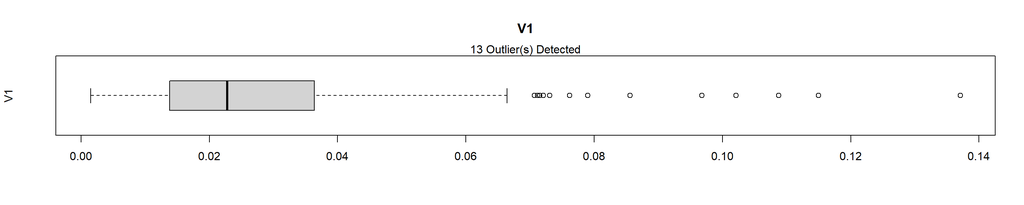

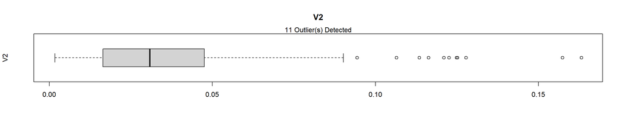

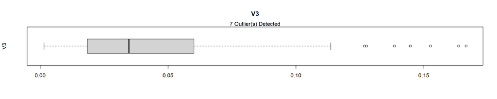

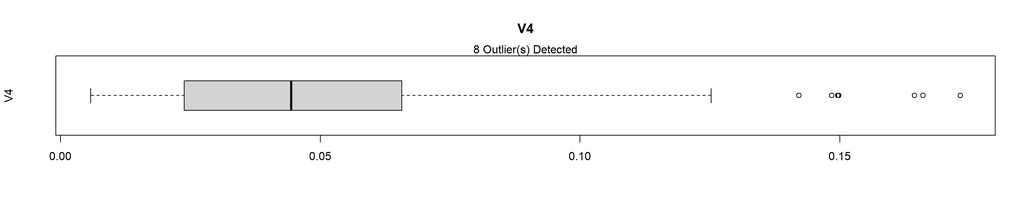

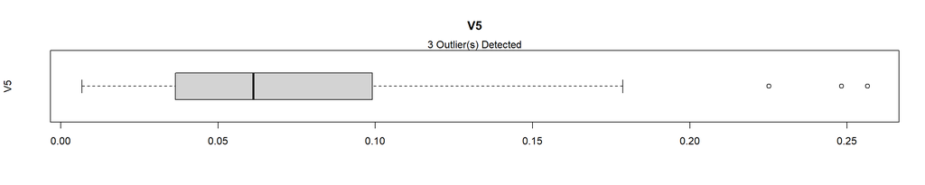

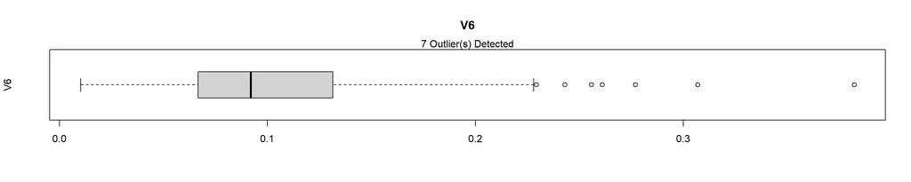

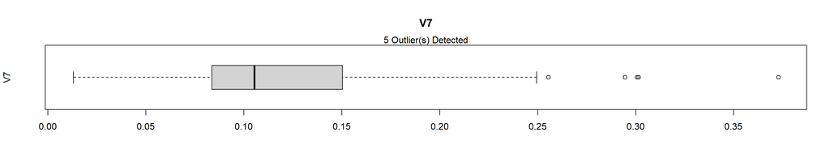

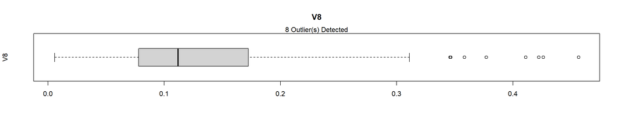

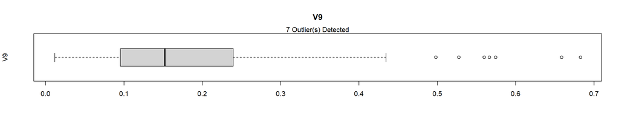

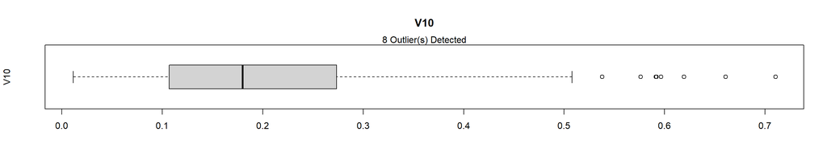

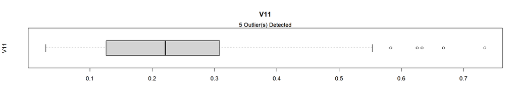

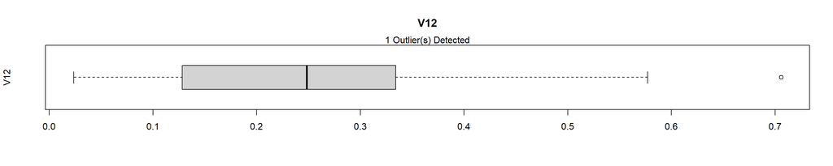

[48 more figures not shown]

```r
##################################
# Loading dataset
##################################
DPA <- Sonar_Train

##################################
# Listing all predictors
##################################
DPA.Predictors <- DPA[,!names(DPA) %in% c("Class")]

##################################
# Listing all numeric predictors
##################################
DPA.Predictors.Numeric <- DPA.Predictors[,sapply(DPA.Predictors, is.numeric)]

##################################
# Identifying outliers for the numeric predictors
##################################
OutlierCountList <- c()

for (i in 1:ncol(DPA.Predictors.Numeric)) {
  Outliers <- boxplot.stats(DPA.Predictors.Numeric[,i])$out
  OutlierCount <- length(Outliers)
  OutlierCountList <- append(OutlierCountList,OutlierCount)
  OutlierIndices <- which(DPA.Predictors.Numeric[,i] %in% c(Outliers))
  boxplot(DPA.Predictors.Numeric[,i],
          ylab = names(DPA.Predictors.Numeric)[i],
          main = names(DPA.Predictors.Numeric)[i],
          horizontal=TRUE)
  mtext(paste0(OutlierCount, " Outlier(s) Detected"))
}
```

```r
OutlierCountSummary <- as.data.frame(cbind(names(DPA.Predictors.Numeric),(OutlierCountList)))
names(OutlierCountSummary) <- c("NumericPredictors","OutlierCount")
OutlierCountSummary$OutlierCount <- as.numeric(as.character(OutlierCountSummary$OutlierCount))
NumericPredictorWithOutlierCount <- nrow(OutlierCountSummary[OutlierCountSummary$OutlierCount>0,])
print(paste0(NumericPredictorWithOutlierCount, " numeric variable(s) were noted with outlier(s)." ))
```

```
## [1] "39 numeric variable(s) were noted with outlier(s)."
```

```r
##################################
# Gathering descriptive statistics
##################################
(DPA_Skimmed <- skim(DPA.Predictors.Numeric))
```

Data summary

| Name | DPA.Predictors.Numeric |
| --- | --- |
| Number of rows | 167 |
| Number of columns | 60 |
| _______________________ |  |
| Column type frequency: |  |
| numeric | 60 |
| ________________________ |  |
| Group variables | None |

**Variable type: numeric**

| skim_variable | n_missing | complete_rate | mean | sd | p0 | p25 | p50 | p75 | p100 | hist |
| --- | --- | --- | --- | --- | --- | --- | --- | --- | --- | --- |
| V1 | 0 | 1 | 0.03 | 0.02 | 0.00 | 0.01 | 0.02 | 0.04 | 0.14 | ▇▃▁▁▁ |
| V2 | 0 | 1 | 0.04 | 0.03 | 0.00 | 0.02 | 0.03 | 0.05 | 0.16 | ▇▅▁▁▁ |
| V3 | 0 | 1 | 0.04 | 0.03 | 0.00 | 0.02 | 0.03 | 0.06 | 0.17 | ▇▆▂▁▁ |
| V4 | 0 | 1 | 0.05 | 0.04 | 0.01 | 0.02 | 0.04 | 0.07 | 0.17 | ▇▆▂▁▁ |
| V5 | 0 | 1 | 0.07 | 0.05 | 0.01 | 0.04 | 0.06 | 0.10 | 0.26 | ▇▆▃▁▁ |
| V6 | 0 | 1 | 0.10 | 0.06 | 0.01 | 0.07 | 0.09 | 0.13 | 0.38 | ▇▇▂▁▁ |
| V7 | 0 | 1 | 0.12 | 0.06 | 0.01 | 0.08 | 0.11 | 0.15 | 0.37 | ▅▇▃▁▁ |
| V8 | 0 | 1 | 0.13 | 0.09 | 0.01 | 0.08 | 0.11 | 0.17 | 0.46 | ▇▇▃▁▁ |
| V9 | 0 | 1 | 0.18 | 0.12 | 0.01 | 0.10 | 0.15 | 0.24 | 0.68 | ▇▆▂▁▁ |
| V10 | 0 | 1 | 0.21 | 0.14 | 0.01 | 0.11 | 0.18 | 0.27 | 0.71 | ▇▆▃▁▁ |
| V11 | 0 | 1 | 0.24 | 0.14 | 0.03 | 0.13 | 0.22 | 0.31 | 0.73 | ▇▇▃▁▁ |
| V12 | 0 | 1 | 0.25 | 0.14 | 0.02 | 0.13 | 0.25 | 0.33 | 0.71 | ▇▇▆▂▁ |
| V13 | 0 | 1 | 0.27 | 0.14 | 0.02 | 0.16 | 0.27 | 0.36 | 0.71 | ▅▇▅▂▁ |
| V14 | 0 | 1 | 0.30 | 0.17 | 0.03 | 0.17 | 0.28 | 0.39 | 1.00 | ▇▇▃▁▁ |
| V15 | 0 | 1 | 0.32 | 0.21 | 0.00 | 0.15 | 0.26 | 0.45 | 1.00 | ▇▆▅▂▁ |
| V16 | 0 | 1 | 0.37 | 0.23 | 0.02 | 0.18 | 0.29 | 0.54 | 1.00 | ▇▆▃▃▁ |
| V17 | 0 | 1 | 0.41 | 0.27 | 0.03 | 0.20 | 0.30 | 0.66 | 1.00 | ▇▇▃▅▃ |
| V18 | 0 | 1 | 0.45 | 0.26 | 0.04 | 0.23 | 0.37 | 0.68 | 1.00 | ▆▇▂▅▃ |
| V19 | 0 | 1 | 0.50 | 0.26 | 0.05 | 0.30 | 0.43 | 0.73 | 1.00 | ▃▇▃▅▅ |
| V20 | 0 | 1 | 0.56 | 0.26 | 0.07 | 0.33 | 0.52 | 0.80 | 1.00 | ▅▇▆▆▇ |
| V21 | 0 | 1 | 0.60 | 0.26 | 0.05 | 0.39 | 0.59 | 0.82 | 1.00 | ▃▆▆▆▇ |
| V22 | 0 | 1 | 0.61 | 0.26 | 0.02 | 0.40 | 0.65 | 0.83 | 1.00 | ▂▅▅▆▇ |
| V23 | 0 | 1 | 0.64 | 0.25 | 0.06 | 0.45 | 0.68 | 0.85 | 1.00 | ▂▃▅▆▇ |
| V24 | 0 | 1 | 0.67 | 0.24 | 0.02 | 0.54 | 0.70 | 0.87 | 1.00 | ▂▂▅▇▇ |
| V25 | 0 | 1 | 0.67 | 0.25 | 0.02 | 0.52 | 0.72 | 0.86 | 1.00 | ▂▂▃▇▇ |
| V26 | 0 | 1 | 0.69 | 0.23 | 0.15 | 0.55 | 0.75 | 0.88 | 1.00 | ▂▂▅▆▇ |
| V27 | 0 | 1 | 0.70 | 0.24 | 0.09 | 0.52 | 0.72 | 0.90 | 1.00 | ▁▂▅▃▇ |
| V28 | 0 | 1 | 0.70 | 0.24 | 0.03 | 0.51 | 0.73 | 0.91 | 1.00 | ▁▂▃▅▇ |
| V29 | 0 | 1 | 0.65 | 0.24 | 0.01 | 0.47 | 0.69 | 0.86 | 1.00 | ▁▂▆▅▇ |
| V30 | 0 | 1 | 0.60 | 0.22 | 0.06 | 0.44 | 0.62 | 0.75 | 1.00 | ▂▅▇▇▅ |
| V31 | 0 | 1 | 0.52 | 0.22 | 0.10 | 0.35 | 0.50 | 0.68 | 0.97 | ▅▇▇▅▅ |
| V32 | 0 | 1 | 0.45 | 0.22 | 0.04 | 0.28 | 0.42 | 0.62 | 0.93 | ▃▇▆▅▃ |
| V33 | 0 | 1 | 0.43 | 0.21 | 0.05 | 0.27 | 0.39 | 0.58 | 1.00 | ▅▇▆▅▁ |
| V34 | 0 | 1 | 0.41 | 0.24 | 0.02 | 0.22 | 0.38 | 0.60 | 0.96 | ▆▇▅▅▂ |
| V35 | 0 | 1 | 0.40 | 0.26 | 0.02 | 0.18 | 0.33 | 0.61 | 1.00 | ▇▇▃▅▂ |
| V36 | 0 | 1 | 0.39 | 0.27 | 0.01 | 0.16 | 0.32 | 0.57 | 1.00 | ▇▆▅▃▂ |
| V37 | 0 | 1 | 0.37 | 0.24 | 0.04 | 0.16 | 0.30 | 0.54 | 0.95 | ▇▅▅▂▂ |
| V38 | 0 | 1 | 0.34 | 0.22 | 0.04 | 0.18 | 0.31 | 0.44 | 1.00 | ▇▇▃▂▁ |
| V39 | 0 | 1 | 0.33 | 0.20 | 0.04 | 0.18 | 0.28 | 0.46 | 0.99 | ▇▇▃▂▁ |
| V40 | 0 | 1 | 0.31 | 0.18 | 0.01 | 0.19 | 0.28 | 0.43 | 0.92 | ▅▇▅▂▁ |
| V41 | 0 | 1 | 0.30 | 0.16 | 0.04 | 0.17 | 0.26 | 0.40 | 0.78 | ▆▇▃▂▁ |
| V42 | 0 | 1 | 0.28 | 0.17 | 0.01 | 0.17 | 0.26 | 0.39 | 0.82 | ▅▇▅▁▁ |
| V43 | 0 | 1 | 0.25 | 0.14 | 0.00 | 0.16 | 0.23 | 0.32 | 0.77 | ▃▇▃▁▁ |
| V44 | 0 | 1 | 0.21 | 0.14 | 0.00 | 0.13 | 0.18 | 0.27 | 0.78 | ▇▇▂▂▁ |
| V45 | 0 | 1 | 0.20 | 0.16 | 0.00 | 0.10 | 0.15 | 0.24 | 0.70 | ▇▆▁▂▁ |
| V46 | 0 | 1 | 0.16 | 0.14 | 0.00 | 0.07 | 0.12 | 0.20 | 0.73 | ▇▃▁▁▁ |
| V47 | 0 | 1 | 0.12 | 0.09 | 0.00 | 0.07 | 0.10 | 0.15 | 0.55 | ▇▅▁▁▁ |
| V48 | 0 | 1 | 0.09 | 0.06 | 0.00 | 0.05 | 0.08 | 0.12 | 0.33 | ▇▇▂▁▁ |
| V49 | 0 | 1 | 0.05 | 0.04 | 0.00 | 0.03 | 0.05 | 0.07 | 0.18 | ▇▇▃▂▁ |
| V50 | 0 | 1 | 0.02 | 0.01 | 0.00 | 0.01 | 0.02 | 0.03 | 0.08 | ▇▇▂▁▁ |
| V51 | 0 | 1 | 0.02 | 0.01 | 0.00 | 0.01 | 0.01 | 0.02 | 0.10 | ▇▃▁▁▁ |
| V52 | 0 | 1 | 0.01 | 0.01 | 0.00 | 0.01 | 0.01 | 0.02 | 0.07 | ▇▃▁▁▁ |
| V53 | 0 | 1 | 0.01 | 0.01 | 0.00 | 0.00 | 0.01 | 0.02 | 0.04 | ▇▅▂▁▁ |
| V54 | 0 | 1 | 0.01 | 0.01 | 0.00 | 0.01 | 0.01 | 0.01 | 0.04 | ▆▇▂▁▁ |
| V55 | 0 | 1 | 0.01 | 0.01 | 0.00 | 0.00 | 0.01 | 0.01 | 0.04 | ▇▃▁▁▁ |
| V56 | 0 | 1 | 0.01 | 0.01 | 0.00 | 0.00 | 0.01 | 0.01 | 0.04 | ▇▅▁▁▁ |
| V57 | 0 | 1 | 0.01 | 0.01 | 0.00 | 0.00 | 0.01 | 0.01 | 0.04 | ▇▅▁▁▁ |
| V58 | 0 | 1 | 0.01 | 0.01 | 0.00 | 0.00 | 0.01 | 0.01 | 0.04 | ▇▃▁▁▁ |
| V59 | 0 | 1 | 0.01 | 0.01 | 0.00 | 0.00 | 0.01 | 0.01 | 0.03 | ▇▆▁▁▁ |
| V60 | 0 | 1 | 0.01 | 0.00 | 0.00 | 0.00 | 0.01 | 0.01 | 0.02 | ▇▆▂▁▁ |

```r
###################################
# Verifying the data dimensions
###################################
dim(DPA.Predictors.Numeric)
```

```
## [1] 167  60
```

### 1.3.2 Zero and Near-Zero Variance

**[A]** Low variance noted for 8 variables from the previous data quality assessment using a lower threshold.  
**[B]** No low variance noted for any variables using a preprocessing summary from the **caret** package. The nearZeroVar method using both the freqCut and uniqueCut criteria set at 95/5 and 10, respectively, were applied on the dataset.

**Code Chunk | Output**

```r
##################################
# Loading dataset
##################################
DPA <- Sonar_Train

##################################
# Gathering descriptive statistics
##################################
(DPA_Skimmed <- skim(DPA))
```

Data summary

| Name | DPA |
| --- | --- |
| Number of rows | 167 |
| Number of columns | 61 |
| _______________________ |  |
| Column type frequency: |  |
| factor | 1 |
| numeric | 60 |
| ________________________ |  |
| Group variables | None |

**Variable type: factor**

| skim_variable | n_missing | complete_rate | ordered | n_unique | top_counts |
| --- | --- | --- | --- | --- | --- |
| Class | 0 | 1 | FALSE | 2 | M: 89, R: 78 |

**Variable type: numeric**

| skim_variable | n_missing | complete_rate | mean | sd | p0 | p25 | p50 | p75 | p100 | hist |
| --- | --- | --- | --- | --- | --- | --- | --- | --- | --- | --- |
| V1 | 0 | 1 | 0.03 | 0.02 | 0.00 | 0.01 | 0.02 | 0.04 | 0.14 | ▇▃▁▁▁ |
| V2 | 0 | 1 | 0.04 | 0.03 | 0.00 | 0.02 | 0.03 | 0.05 | 0.16 | ▇▅▁▁▁ |
| V3 | 0 | 1 | 0.04 | 0.03 | 0.00 | 0.02 | 0.03 | 0.06 | 0.17 | ▇▆▂▁▁ |
| V4 | 0 | 1 | 0.05 | 0.04 | 0.01 | 0.02 | 0.04 | 0.07 | 0.17 | ▇▆▂▁▁ |
| V5 | 0 | 1 | 0.07 | 0.05 | 0.01 | 0.04 | 0.06 | 0.10 | 0.26 | ▇▆▃▁▁ |
| V6 | 0 | 1 | 0.10 | 0.06 | 0.01 | 0.07 | 0.09 | 0.13 | 0.38 | ▇▇▂▁▁ |
| V7 | 0 | 1 | 0.12 | 0.06 | 0.01 | 0.08 | 0.11 | 0.15 | 0.37 | ▅▇▃▁▁ |
| V8 | 0 | 1 | 0.13 | 0.09 | 0.01 | 0.08 | 0.11 | 0.17 | 0.46 | ▇▇▃▁▁ |
| V9 | 0 | 1 | 0.18 | 0.12 | 0.01 | 0.10 | 0.15 | 0.24 | 0.68 | ▇▆▂▁▁ |
| V10 | 0 | 1 | 0.21 | 0.14 | 0.01 | 0.11 | 0.18 | 0.27 | 0.71 | ▇▆▃▁▁ |
| V11 | 0 | 1 | 0.24 | 0.14 | 0.03 | 0.13 | 0.22 | 0.31 | 0.73 | ▇▇▃▁▁ |
| V12 | 0 | 1 | 0.25 | 0.14 | 0.02 | 0.13 | 0.25 | 0.33 | 0.71 | ▇▇▆▂▁ |
| V13 | 0 | 1 | 0.27 | 0.14 | 0.02 | 0.16 | 0.27 | 0.36 | 0.71 | ▅▇▅▂▁ |
| V14 | 0 | 1 | 0.30 | 0.17 | 0.03 | 0.17 | 0.28 | 0.39 | 1.00 | ▇▇▃▁▁ |
| V15 | 0 | 1 | 0.32 | 0.21 | 0.00 | 0.15 | 0.26 | 0.45 | 1.00 | ▇▆▅▂▁ |
| V16 | 0 | 1 | 0.37 | 0.23 | 0.02 | 0.18 | 0.29 | 0.54 | 1.00 | ▇▆▃▃▁ |
| V17 | 0 | 1 | 0.41 | 0.27 | 0.03 | 0.20 | 0.30 | 0.66 | 1.00 | ▇▇▃▅▃ |
| V18 | 0 | 1 | 0.45 | 0.26 | 0.04 | 0.23 | 0.37 | 0.68 | 1.00 | ▆▇▂▅▃ |
| V19 | 0 | 1 | 0.50 | 0.26 | 0.05 | 0.30 | 0.43 | 0.73 | 1.00 | ▃▇▃▅▅ |
| V20 | 0 | 1 | 0.56 | 0.26 | 0.07 | 0.33 | 0.52 | 0.80 | 1.00 | ▅▇▆▆▇ |
| V21 | 0 | 1 | 0.60 | 0.26 | 0.05 | 0.39 | 0.59 | 0.82 | 1.00 | ▃▆▆▆▇ |
| V22 | 0 | 1 | 0.61 | 0.26 | 0.02 | 0.40 | 0.65 | 0.83 | 1.00 | ▂▅▅▆▇ |
| V23 | 0 | 1 | 0.64 | 0.25 | 0.06 | 0.45 | 0.68 | 0.85 | 1.00 | ▂▃▅▆▇ |
| V24 | 0 | 1 | 0.67 | 0.24 | 0.02 | 0.54 | 0.70 | 0.87 | 1.00 | ▂▂▅▇▇ |
| V25 | 0 | 1 | 0.67 | 0.25 | 0.02 | 0.52 | 0.72 | 0.86 | 1.00 | ▂▂▃▇▇ |
| V26 | 0 | 1 | 0.69 | 0.23 | 0.15 | 0.55 | 0.75 | 0.88 | 1.00 | ▂▂▅▆▇ |
| V27 | 0 | 1 | 0.70 | 0.24 | 0.09 | 0.52 | 0.72 | 0.90 | 1.00 | ▁▂▅▃▇ |
| V28 | 0 | 1 | 0.70 | 0.24 | 0.03 | 0.51 | 0.73 | 0.91 | 1.00 | ▁▂▃▅▇ |
| V29 | 0 | 1 | 0.65 | 0.24 | 0.01 | 0.47 | 0.69 | 0.86 | 1.00 | ▁▂▆▅▇ |
| V30 | 0 | 1 | 0.60 | 0.22 | 0.06 | 0.44 | 0.62 | 0.75 | 1.00 | ▂▅▇▇▅ |
| V31 | 0 | 1 | 0.52 | 0.22 | 0.10 | 0.35 | 0.50 | 0.68 | 0.97 | ▅▇▇▅▅ |
| V32 | 0 | 1 | 0.45 | 0.22 | 0.04 | 0.28 | 0.42 | 0.62 | 0.93 | ▃▇▆▅▃ |
| V33 | 0 | 1 | 0.43 | 0.21 | 0.05 | 0.27 | 0.39 | 0.58 | 1.00 | ▅▇▆▅▁ |
| V34 | 0 | 1 | 0.41 | 0.24 | 0.02 | 0.22 | 0.38 | 0.60 | 0.96 | ▆▇▅▅▂ |
| V35 | 0 | 1 | 0.40 | 0.26 | 0.02 | 0.18 | 0.33 | 0.61 | 1.00 | ▇▇▃▅▂ |
| V36 | 0 | 1 | 0.39 | 0.27 | 0.01 | 0.16 | 0.32 | 0.57 | 1.00 | ▇▆▅▃▂ |
| V37 | 0 | 1 | 0.37 | 0.24 | 0.04 | 0.16 | 0.30 | 0.54 | 0.95 | ▇▅▅▂▂ |
| V38 | 0 | 1 | 0.34 | 0.22 | 0.04 | 0.18 | 0.31 | 0.44 | 1.00 | ▇▇▃▂▁ |
| V39 | 0 | 1 | 0.33 | 0.20 | 0.04 | 0.18 | 0.28 | 0.46 | 0.99 | ▇▇▃▂▁ |
| V40 | 0 | 1 | 0.31 | 0.18 | 0.01 | 0.19 | 0.28 | 0.43 | 0.92 | ▅▇▅▂▁ |
| V41 | 0 | 1 | 0.30 | 0.16 | 0.04 | 0.17 | 0.26 | 0.40 | 0.78 | ▆▇▃▂▁ |
| V42 | 0 | 1 | 0.28 | 0.17 | 0.01 | 0.17 | 0.26 | 0.39 | 0.82 | ▅▇▅▁▁ |
| V43 | 0 | 1 | 0.25 | 0.14 | 0.00 | 0.16 | 0.23 | 0.32 | 0.77 | ▃▇▃▁▁ |
| V44 | 0 | 1 | 0.21 | 0.14 | 0.00 | 0.13 | 0.18 | 0.27 | 0.78 | ▇▇▂▂▁ |
| V45 | 0 | 1 | 0.20 | 0.16 | 0.00 | 0.10 | 0.15 | 0.24 | 0.70 | ▇▆▁▂▁ |
| V46 | 0 | 1 | 0.16 | 0.14 | 0.00 | 0.07 | 0.12 | 0.20 | 0.73 | ▇▃▁▁▁ |
| V47 | 0 | 1 | 0.12 | 0.09 | 0.00 | 0.07 | 0.10 | 0.15 | 0.55 | ▇▅▁▁▁ |
| V48 | 0 | 1 | 0.09 | 0.06 | 0.00 | 0.05 | 0.08 | 0.12 | 0.33 | ▇▇▂▁▁ |
| V49 | 0 | 1 | 0.05 | 0.04 | 0.00 | 0.03 | 0.05 | 0.07 | 0.18 | ▇▇▃▂▁ |
| V50 | 0 | 1 | 0.02 | 0.01 | 0.00 | 0.01 | 0.02 | 0.03 | 0.08 | ▇▇▂▁▁ |
| V51 | 0 | 1 | 0.02 | 0.01 | 0.00 | 0.01 | 0.01 | 0.02 | 0.10 | ▇▃▁▁▁ |
| V52 | 0 | 1 | 0.01 | 0.01 | 0.00 | 0.01 | 0.01 | 0.02 | 0.07 | ▇▃▁▁▁ |
| V53 | 0 | 1 | 0.01 | 0.01 | 0.00 | 0.00 | 0.01 | 0.02 | 0.04 | ▇▅▂▁▁ |
| V54 | 0 | 1 | 0.01 | 0.01 | 0.00 | 0.01 | 0.01 | 0.01 | 0.04 | ▆▇▂▁▁ |
| V55 | 0 | 1 | 0.01 | 0.01 | 0.00 | 0.00 | 0.01 | 0.01 | 0.04 | ▇▃▁▁▁ |
| V56 | 0 | 1 | 0.01 | 0.01 | 0.00 | 0.00 | 0.01 | 0.01 | 0.04 | ▇▅▁▁▁ |
| V57 | 0 | 1 | 0.01 | 0.01 | 0.00 | 0.00 | 0.01 | 0.01 | 0.04 | ▇▅▁▁▁ |
| V58 | 0 | 1 | 0.01 | 0.01 | 0.00 | 0.00 | 0.01 | 0.01 | 0.04 | ▇▃▁▁▁ |
| V59 | 0 | 1 | 0.01 | 0.01 | 0.00 | 0.00 | 0.01 | 0.01 | 0.03 | ▇▆▁▁▁ |
| V60 | 0 | 1 | 0.01 | 0.00 | 0.00 | 0.00 | 0.01 | 0.01 | 0.02 | ▇▆▂▁▁ |

```r
##################################
# Identifying columns with low variance
###################################
DPA_LowVariance <- nearZeroVar(DPA,
                               freqCut = 95/5,
                               uniqueCut = 10,
                               saveMetrics= TRUE)
(DPA_LowVariance[DPA_LowVariance$nzv,])
```

```
## [1] freqRatio     percentUnique zeroVar       nzv
## <0 rows> (or 0-length row.names)
```

```r
if ((nrow(DPA_LowVariance[DPA_LowVariance$nzv,]))==0){

  print("No low variance predictors noted.")

} else {

  print(paste0("Low variance observed for ",
               (nrow(DPA_LowVariance[DPA_LowVariance$nzv,])),
               " numeric variable(s) with First.Second.Mode.Ratio>4 and Unique.Count.Ratio<0.10."))

  DPA_LowVarianceForRemoval <- (nrow(DPA_LowVariance[DPA_LowVariance$nzv,]))

  print(paste0("Low variance can be resolved by removing ",
               (nrow(DPA_LowVariance[DPA_LowVariance$nzv,])),
               " numeric variable(s)."))

  for (j in 1:DPA_LowVarianceForRemoval) {
  DPA_LowVarianceRemovedVariable <- rownames(DPA_LowVariance[DPA_LowVariance$nzv,])[j]
  print(paste0("Variable ",
               j,
               " for removal: ",
               DPA_LowVarianceRemovedVariable))
  }

  DPA %>%
  skim() %>%
  dplyr::filter(skim_variable %in% rownames(DPA_LowVariance[DPA_LowVariance$nzv,]))

  ##################################
  # Filtering out columns with low variance
  #################################
  DPA_ExcludedLowVariance <- DPA[,!names(DPA) %in% rownames(DPA_LowVariance[DPA_LowVariance$nzv,])]

  ##################################
  # Gathering descriptive statistics
  ##################################
  (DPA_ExcludedLowVariance_Skimmed <- skim(DPA_ExcludedLowVariance))

  ###################################
  # Verifying the data dimensions
  ###################################
  dim(DPA_ExcludedLowVariance)

}
```

```
## [1] "No low variance predictors noted."
```

### 1.3.3 Collinearity

**[A]** No high correlation > 95% were noted for any variable as confirmed using the preprocessing summaries from the **caret** and **lares** packages.

**Code Chunk | Output**

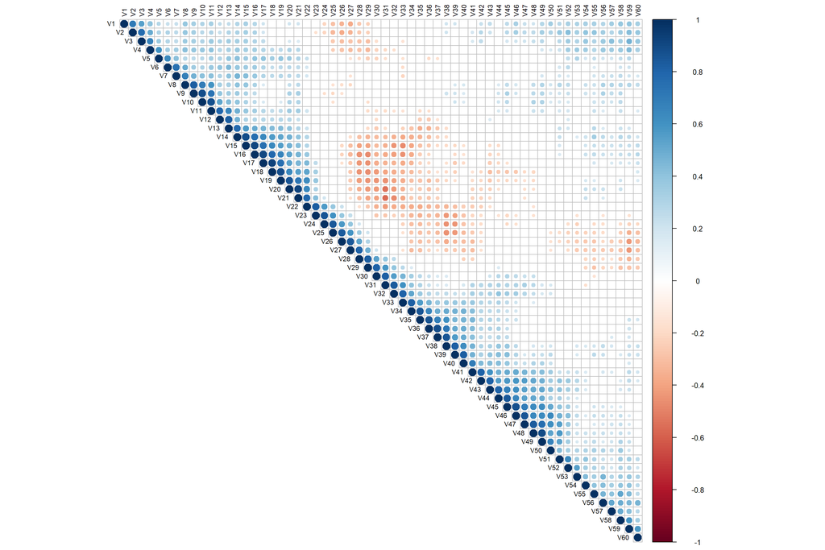

```r
##################################
# Loading dataset
##################################
DPA <- Sonar_Train

##################################
# Listing all predictors
##################################
DPA.Predictors <- DPA[,!names(DPA) %in% c("Class")]

##################################
# Listing all numeric predictors
##################################
DPA.Predictors.Numeric <- DPA.Predictors[,sapply(DPA.Predictors, is.numeric)]

##################################
# Visualizing pairwise correlation between predictors
##################################
DPA_CorrelationTest <- cor.mtest(DPA.Predictors.Numeric,
                       method = "pearson",
                       conf.level = .95)

corrplot(cor(DPA.Predictors.Numeric,
             method = "pearson",
             use="pairwise.complete.obs"),
         method = "circle",
         type = "upper",
         order = "original",
         tl.col = "black",
         tl.cex = 0.75,
         tl.srt = 90,
         sig.level = 0.05,
         p.mat = DPA_CorrelationTest$p,
         insig = "blank")
```

```r
##################################
# Identifying the highly correlated variables
##################################
DPA_Correlation <-  cor(DPA.Predictors.Numeric,
                        method = "pearson",
                        use="pairwise.complete.obs")
(DPA_HighlyCorrelatedCount <- sum(abs(DPA_Correlation[upper.tri(DPA_Correlation)]) > 0.95))
```

```
## [1] 0
```

```r
if (DPA_HighlyCorrelatedCount == 0) {

  print("No highly correlated predictors noted.")

} else {
  print(paste0("High correlation observed for ",
               (DPA_HighlyCorrelatedCount),
               " pairs of numeric variable(s) with Correlation.Coefficient>0.95."))

  (DPA_HighlyCorrelatedPairs <- corr_cross(DPA.Predictors.Numeric,
  max_pvalue = 0.05,
  top = DPA_HighlyCorrelatedCount,
  rm.na = TRUE,
  grid = FALSE
))

}
```

```
## [1] "No highly correlated predictors noted."
```

```r
if (DPA_HighlyCorrelatedCount > 0) {
  DPA_HighlyCorrelated <- findCorrelation(DPA_Correlation, cutoff = 0.95)

  (DPA_HighlyCorrelatedForRemoval <- length(DPA_HighlyCorrelated))

  print(paste0("High correlation can be resolved by removing ",
               (DPA_HighlyCorrelatedForRemoval),
               " numeric variable(s)."))

  for (j in 1:DPA_HighlyCorrelatedForRemoval) {
  DPA_HighlyCorrelatedRemovedVariable <- colnames(DPA.Predictors.Numeric)[DPA_HighlyCorrelated[j]]
  print(paste0("Variable ",
               j,
               " for removal: ",
               DPA_HighlyCorrelatedRemovedVariable))
  }

  ##################################
  # Filtering out columns with high correlation
  #################################
  DPA_ExcludedHighCorrelation <- DPA[,-DPA_HighlyCorrelated]

  ##################################
  # Gathering descriptive statistics
  ##################################
  (DPA_ExcludedHighCorrelation_Skimmed <- skim(DPA_ExcludedHighCorrelation))

  ###################################
  # Verifying the data dimensions
  ###################################
  dim(DPA_ExcludedHighCorrelation)

}
```

### 1.3.4 Linear Dependencies

**[A]** No linear dependencies noted for any subset of variables using the preprocessing summary from the **caret** package applying the findLinearCombos method which utilizes the QR decomposition of a matrix to enumerate sets of linear combinations (if they exist).

**Code Chunk | Output**

```r
##################################
# Loading dataset
##################################
DPA <- Sonar_Train

##################################
# Listing all predictors
##################################
DPA.Predictors <- DPA[,!names(DPA) %in% c("Class")]

##################################
# Listing all numeric predictors
##################################
DPA.Predictors.Numeric <- DPA.Predictors[,sapply(DPA.Predictors, is.numeric)]

##################################
# Identifying the linearly dependent variables
##################################
DPA_LinearlyDependent <- findLinearCombos(DPA.Predictors.Numeric)

(DPA_LinearlyDependentCount <- length(DPA_LinearlyDependent$linearCombos))
```

```
## [1] 0
```

```r
if (DPA_LinearlyDependentCount == 0) {
  print("No linearly dependent predictors noted.")
} else {
  print(paste0("Linear dependency observed for ",
               (DPA_LinearlyDependentCount),
               " subset(s) of numeric variable(s)."))

  for (i in 1:DPA_LinearlyDependentCount) {
    DPA_LinearlyDependentSubset <- colnames(DPA.Predictors.Numeric)[DPA_LinearlyDependent$linearCombos[[i]]]
    print(paste0("Linear dependent variable(s) for subset ",
                 i,
                 " include: ",
                 DPA_LinearlyDependentSubset))
  }

}
```

```
## [1] "No linearly dependent predictors noted."
```

```r
##################################
# Identifying the linearly dependent variables for removal
##################################

if (DPA_LinearlyDependentCount > 0) {
  DPA_LinearlyDependent <- findLinearCombos(DPA.Predictors.Numeric)

  DPA_LinearlyDependentForRemoval <- length(DPA_LinearlyDependent$remove)

  print(paste0("Linear dependency can be resolved by removing ",
               (DPA_LinearlyDependentForRemoval),
               " numeric variable(s)."))

  for (j in 1:DPA_LinearlyDependentForRemoval) {
  DPA_LinearlyDependentRemovedVariable <- colnames(DPA.Predictors.Numeric)[DPA_LinearlyDependent$remove[j]]
  print(paste0("Variable ",
               j,
               " for removal: ",
               DPA_LinearlyDependentRemovedVariable))
  }

  ##################################
  # Filtering out columns with linear dependency
  #################################
  DPA_ExcludedLinearlyDependent <- DPA[,-DPA_LinearlyDependent$remove]

  ##################################
  # Gathering descriptive statistics
  ##################################
  (DPA_ExcludedLinearlyDependent_Skimmed <- skim(DPA_ExcludedLinearlyDependent))

  ###################################
  # Verifying the data dimensions
  ###################################
  dim(DPA_ExcludedLinearlyDependent)

} else {

  ###################################
  # Verifying the data dimensions
  ###################################
  dim(DPA)

}
```

```
## [1] 167  61
```

### 1.3.5 Shape Transformation

**[A]** A number of numeric variables in the dataset were observed to be right-skewed which required shape transformation for data distribution stability. Considering that all numeric variables were strictly positive values, the BoxCox method from the **caret** package was used to transform their distributional shapes.

**Code Chunk | Output**

```r
##################################
# Loading dataset
##################################
DPA <- Sonar_Train

##################################
# Listing all predictors
##################################
DPA.Predictors <- DPA[,!names(DPA) %in% c("Class")]

##################################
# Listing all numeric predictors
##################################
DPA.Predictors.Numeric <- DPA.Predictors[,sapply(DPA.Predictors, is.numeric)]

##################################
# Applying a Box-Cox transformation
##################################
DPA_BoxCox <- preProcess(DPA.Predictors.Numeric, method = c("BoxCox"))
DPA_BoxCoxTransformed <- predict(DPA_BoxCox, DPA.Predictors.Numeric)

##################################
# Gathering descriptive statistics
##################################
(DPA_BoxCoxTransformedSkimmed <- skim(DPA_BoxCoxTransformed))
```

Data summary

| Name | DPA_BoxCoxTransformed |
| --- | --- |
| Number of rows | 167 |
| Number of columns | 60 |
| _______________________ |  |
| Column type frequency: |  |
| numeric | 60 |
| ________________________ |  |
| Group variables | None |

**Variable type: numeric**

| skim_variable | n_missing | complete_rate | mean | sd | p0 | p25 | p50 | p75 | p100 | hist |
| --- | --- | --- | --- | --- | --- | --- | --- | --- | --- | --- |
| V1 | 0 | 1 | -3.79 | 0.75 | -6.50 | -4.28 | -3.78 | -3.31 | -1.99 | ▁▂▇▇▂ |
| V2 | 0 | 1 | -2.53 | 0.42 | -3.60 | -2.80 | -2.51 | -2.28 | -1.52 | ▁▅▇▆▂ |
| V3 | 0 | 1 | -2.11 | 0.29 | -2.86 | -2.33 | -2.12 | -1.90 | -1.39 | ▂▅▇▅▂ |
| V4 | 0 | 1 | -2.35 | 0.40 | -3.21 | -2.63 | -2.32 | -2.10 | -1.48 | ▂▅▇▅▂ |
| V5 | 0 | 1 | -1.89 | 0.31 | -2.59 | -2.10 | -1.89 | -1.67 | -1.12 | ▂▇▇▆▂ |
| V6 | 0 | 1 | -1.53 | 0.23 | -2.10 | -1.65 | -1.54 | -1.39 | -0.80 | ▂▆▇▂▁ |
| V7 | 0 | 1 | -1.46 | 0.22 | -2.06 | -1.57 | -1.48 | -1.33 | -0.82 | ▁▃▇▃▁ |
| V8 | 0 | 1 | -1.43 | 0.28 | -2.18 | -1.60 | -1.46 | -1.26 | -0.67 | ▁▅▇▅▁ |
| V9 | 0 | 1 | -1.57 | 0.47 | -2.95 | -1.87 | -1.57 | -1.24 | -0.37 | ▁▃▇▅▁ |
| V10 | 0 | 1 | -1.34 | 0.41 | -2.46 | -1.63 | -1.34 | -1.07 | -0.32 | ▁▅▇▅▂ |
| V11 | 0 | 1 | -1.25 | 0.38 | -2.18 | -1.54 | -1.21 | -0.99 | -0.30 | ▂▆▇▆▂ |
| V12 | 0 | 1 | -1.05 | 0.29 | -1.69 | -1.28 | -1.00 | -0.84 | -0.32 | ▃▆▇▅▂ |
| V13 | 0 | 1 | -0.99 | 0.28 | -1.73 | -1.19 | -0.97 | -0.80 | -0.31 | ▁▅▇▅▂ |
| V14 | 0 | 1 | -1.10 | 0.40 | -2.20 | -1.39 | -1.06 | -0.81 | 0.00 | ▁▅▇▆▁ |
| V15 | 0 | 1 | -1.02 | 0.44 | -2.25 | -1.31 | -1.04 | -0.68 | 0.00 | ▁▅▇▇▂ |
| V16 | 0 | 1 | -0.97 | 0.48 | -2.37 | -1.33 | -1.03 | -0.57 | 0.00 | ▁▅▇▆▅ |
| V17 | 0 | 1 | -0.97 | 0.57 | -2.44 | -1.37 | -1.06 | -0.40 | 0.00 | ▁▅▇▅▇ |
| V18 | 0 | 1 | -0.81 | 0.48 | -2.09 | -1.18 | -0.87 | -0.37 | 0.00 | ▁▃▇▃▆ |
| V19 | 0 | 1 | -0.64 | 0.38 | -1.56 | -0.91 | -0.69 | -0.29 | 0.00 | ▂▅▇▅▇ |
| V20 | 0 | 1 | 0.56 | 0.26 | 0.07 | 0.33 | 0.52 | 0.80 | 1.00 | ▅▇▆▆▇ |
| V21 | 0 | 1 | 0.60 | 0.26 | 0.05 | 0.39 | 0.59 | 0.82 | 1.00 | ▃▆▆▆▇ |
| V22 | 0 | 1 | 0.61 | 0.26 | 0.02 | 0.40 | 0.65 | 0.83 | 1.00 | ▂▅▅▆▇ |
| V23 | 0 | 1 | -0.33 | 0.21 | -0.75 | -0.50 | -0.30 | -0.14 | 0.00 | ▃▆▇▇▇ |
| V24 | 0 | 1 | -0.29 | 0.19 | -0.71 | -0.41 | -0.28 | -0.13 | 0.00 | ▃▃▇▆▇ |
| V25 | 0 | 1 | -0.28 | 0.18 | -0.66 | -0.41 | -0.26 | -0.13 | 0.00 | ▅▃▆▇▇ |
| V26 | 0 | 1 | -0.25 | 0.16 | -0.56 | -0.38 | -0.23 | -0.11 | 0.00 | ▅▅▆▇▇ |
| V27 | 0 | 1 | -0.26 | 0.19 | -0.65 | -0.42 | -0.26 | -0.10 | 0.00 | ▂▃▅▃▇ |
| V28 | 0 | 1 | -0.27 | 0.20 | -0.71 | -0.44 | -0.26 | -0.09 | 0.00 | ▂▅▅▅▇ |
| V29 | 0 | 1 | -0.31 | 0.20 | -0.77 | -0.48 | -0.29 | -0.14 | 0.00 | ▂▆▅▆▇ |
| V30 | 0 | 1 | 0.60 | 0.22 | 0.06 | 0.44 | 0.62 | 0.75 | 1.00 | ▂▅▇▇▅ |
| V31 | 0 | 1 | -0.57 | 0.29 | -1.25 | -0.78 | -0.57 | -0.34 | -0.03 | ▂▆▇▇▆ |
| V32 | 0 | 1 | -0.67 | 0.32 | -1.42 | -0.89 | -0.67 | -0.41 | -0.07 | ▂▅▇▆▅ |
| V33 | 0 | 1 | -0.74 | 0.33 | -1.56 | -0.96 | -0.75 | -0.48 | 0.00 | ▁▆▇▇▃ |
| V34 | 0 | 1 | -0.77 | 0.38 | -1.71 | -1.07 | -0.77 | -0.44 | -0.04 | ▂▆▇▆▅ |
| V35 | 0 | 1 | -0.87 | 0.48 | -1.95 | -1.23 | -0.89 | -0.45 | 0.00 | ▂▆▇▆▆ |
| V36 | 0 | 1 | -0.90 | 0.49 | -2.14 | -1.31 | -0.92 | -0.51 | 0.00 | ▁▇▇▇▆ |
| V37 | 0 | 1 | -0.99 | 0.52 | -2.11 | -1.41 | -1.00 | -0.56 | -0.05 | ▂▇▆▇▆ |
| V38 | 0 | 1 | -1.09 | 0.52 | -2.40 | -1.46 | -1.04 | -0.76 | 0.00 | ▂▆▇▇▃ |
| V39 | 0 | 1 | -1.03 | 0.44 | -2.09 | -1.34 | -1.05 | -0.69 | -0.01 | ▂▇▇▆▂ |
| V40 | 0 | 1 | -0.93 | 0.32 | -1.78 | -1.12 | -0.94 | -0.70 | -0.09 | ▁▅▇▅▁ |
| V41 | 0 | 1 | -1.02 | 0.34 | -1.78 | -1.27 | -1.03 | -0.76 | -0.24 | ▂▆▇▅▂ |
| V42 | 0 | 1 | -0.98 | 0.32 | -1.85 | -1.17 | -0.98 | -0.76 | -0.18 | ▁▃▇▆▁ |
| V43 | 0 | 1 | 0.25 | 0.14 | 0.00 | 0.16 | 0.23 | 0.32 | 0.77 | ▃▇▃▁▁ |
| V44 | 0 | 1 | 0.21 | 0.14 | 0.00 | 0.13 | 0.18 | 0.27 | 0.78 | ▇▇▂▂▁ |
| V45 | 0 | 1 | 0.20 | 0.16 | 0.00 | 0.10 | 0.15 | 0.24 | 0.70 | ▇▆▁▂▁ |
| V46 | 0 | 1 | 0.16 | 0.14 | 0.00 | 0.07 | 0.12 | 0.20 | 0.73 | ▇▃▁▁▁ |
| V47 | 0 | 1 | 0.12 | 0.09 | 0.00 | 0.07 | 0.10 | 0.15 | 0.55 | ▇▅▁▁▁ |
| V48 | 0 | 1 | 0.09 | 0.06 | 0.00 | 0.05 | 0.08 | 0.12 | 0.33 | ▇▇▂▁▁ |
| V49 | 0 | 1 | 0.05 | 0.04 | 0.00 | 0.03 | 0.05 | 0.07 | 0.18 | ▇▇▃▂▁ |
| V50 | 0 | 1 | 0.02 | 0.01 | 0.00 | 0.01 | 0.02 | 0.03 | 0.08 | ▇▇▂▁▁ |
| V51 | 0 | 1 | 0.02 | 0.01 | 0.00 | 0.01 | 0.01 | 0.02 | 0.10 | ▇▃▁▁▁ |
| V52 | 0 | 1 | -4.54 | 0.71 | -7.13 | -4.93 | -4.49 | -4.09 | -2.65 | ▁▂▇▇▂ |
| V53 | 0 | 1 | -3.07 | 0.30 | -3.91 | -3.29 | -3.10 | -2.83 | -2.39 | ▁▅▇▇▂ |
| V54 | 0 | 1 | -2.52 | 0.17 | -2.91 | -2.64 | -2.51 | -2.41 | -2.11 | ▂▃▇▃▂ |
| V55 | 0 | 1 | -3.13 | 0.28 | -3.87 | -3.33 | -3.12 | -2.93 | -2.31 | ▁▆▇▅▁ |
| V56 | 0 | 1 | -2.58 | 0.16 | -3.01 | -2.68 | -2.58 | -2.49 | -2.07 | ▁▆▇▃▁ |
| V57 | 0 | 1 | -3.18 | 0.27 | -4.01 | -3.37 | -3.20 | -3.00 | -2.44 | ▁▃▇▅▁ |
| V58 | 0 | 1 | -5.11 | 0.81 | -8.11 | -5.63 | -5.12 | -4.57 | -3.12 | ▁▂▇▇▂ |
| V59 | 0 | 1 | -2.61 | 0.18 | -3.12 | -2.72 | -2.62 | -2.50 | -2.18 | ▁▃▇▅▂ |
| V60 | 0 | 1 | -5.34 | 0.70 | -7.42 | -5.81 | -5.28 | -4.77 | -3.83 | ▁▃▆▇▂ |

```r
###################################
# Verifying the data dimensions
###################################
dim(DPA_BoxCoxTransformed)
```

```
## [1] 167  60
```

### 1.3.6 Centering and Scaling

**[A]** To maintain numerical stability during modelling, centering and scaling transformations were applied on the transformed numeric variables. The center method from the **caret** package was implemented which subtracts the average value of a numeric variable to all the values. As a result of centering, the variables had zero mean values. In addition, the scale method, also from the **caret** package, was applied which performs a center transformation with each value of the variable divided by its standard deviation. Scaling the data coerced the values to have a common standard deviation of one.

**Code Chunk | Output**

```r
##################################
# Loading dataset
##################################
DPA <- Sonar_Train

##################################
# Listing all predictors
##################################
DPA.Predictors <- DPA[,!names(DPA) %in% c("Class")]

##################################
# Listing all numeric predictors
##################################
DPA.Predictors.Numeric <- DPA.Predictors[,sapply(DPA.Predictors, is.numeric)]

##################################
# Applying a Box-Cox transformation
##################################
DPA_BoxCox <- preProcess(DPA.Predictors.Numeric, method = c("BoxCox"))
DPA_BoxCoxTransformed <- predict(DPA_BoxCox, DPA.Predictors.Numeric)

##################################
# Applying a center and scale data transformation
##################################
DPA.Predictors.Numeric_BoxCoxTransformed_CenteredScaled <- preProcess(DPA_BoxCoxTransformed, method = c("center","scale"))
DPA.Predictors.Numeric_BoxCoxTransformed_CenteredScaledTransformed <- predict(DPA.Predictors.Numeric_BoxCoxTransformed_CenteredScaled, DPA_BoxCoxTransformed)

##################################
# Gathering descriptive statistics
##################################
(DPA.Predictors.Numeric_BoxCoxTransformed_CenteredScaledTransformedSkimmed <- skim(DPA.Predictors.Numeric_BoxCoxTransformed_CenteredScaledTransformed))
```

Data summary

| Name | DPA.Predictors.Numeric_Bo… |
| --- | --- |
| Number of rows | 167 |
| Number of columns | 60 |
| _______________________ |  |
| Column type frequency: |  |
| numeric | 60 |
| ________________________ |  |
| Group variables | None |

**Variable type: numeric**

| skim_variable | n_missing | complete_rate | mean | sd | p0 | p25 | p50 | p75 | p100 | hist |
| --- | --- | --- | --- | --- | --- | --- | --- | --- | --- | --- |
| V1 | 0 | 1 | 0 | 1 | -3.60 | -0.65 | 0.02 | 0.64 | 2.40 | ▁▂▇▇▂ |
| V2 | 0 | 1 | 0 | 1 | -2.55 | -0.65 | 0.05 | 0.59 | 2.40 | ▁▅▇▆▂ |
| V3 | 0 | 1 | 0 | 1 | -2.55 | -0.74 | -0.02 | 0.72 | 2.46 | ▂▅▇▅▂ |
| V4 | 0 | 1 | 0 | 1 | -2.17 | -0.71 | 0.08 | 0.62 | 2.18 | ▂▅▇▅▂ |
| V5 | 0 | 1 | 0 | 1 | -2.29 | -0.68 | 0.00 | 0.73 | 2.53 | ▂▇▇▆▂ |
| V6 | 0 | 1 | 0 | 1 | -2.54 | -0.55 | -0.03 | 0.62 | 3.25 | ▂▆▇▂▁ |
| V7 | 0 | 1 | 0 | 1 | -2.75 | -0.52 | -0.11 | 0.61 | 2.96 | ▁▃▇▃▁ |
| V8 | 0 | 1 | 0 | 1 | -2.70 | -0.60 | -0.10 | 0.61 | 2.72 | ▁▅▇▅▁ |
| V9 | 0 | 1 | 0 | 1 | -2.94 | -0.64 | 0.01 | 0.71 | 2.58 | ▁▃▇▅▁ |
| V10 | 0 | 1 | 0 | 1 | -2.72 | -0.69 | 0.01 | 0.66 | 2.48 | ▁▅▇▅▂ |
| V11 | 0 | 1 | 0 | 1 | -2.43 | -0.77 | 0.09 | 0.67 | 2.48 | ▂▆▇▆▂ |
| V12 | 0 | 1 | 0 | 1 | -2.22 | -0.81 | 0.14 | 0.69 | 2.48 | ▃▆▇▅▂ |
| V13 | 0 | 1 | 0 | 1 | -2.64 | -0.72 | 0.09 | 0.68 | 2.45 | ▁▅▇▅▂ |
| V14 | 0 | 1 | 0 | 1 | -2.76 | -0.72 | 0.09 | 0.71 | 2.74 | ▁▅▇▆▁ |
| V15 | 0 | 1 | 0 | 1 | -2.79 | -0.67 | -0.04 | 0.76 | 2.30 | ▁▅▇▇▂ |
| V16 | 0 | 1 | 0 | 1 | -2.90 | -0.75 | -0.12 | 0.82 | 2.00 | ▁▅▇▆▅ |
| V17 | 0 | 1 | 0 | 1 | -2.59 | -0.70 | -0.16 | 1.00 | 1.70 | ▁▅▇▅▇ |
| V18 | 0 | 1 | 0 | 1 | -2.68 | -0.76 | -0.12 | 0.93 | 1.71 | ▁▃▇▃▆ |
| V19 | 0 | 1 | 0 | 1 | -2.40 | -0.71 | -0.13 | 0.90 | 1.66 | ▂▅▇▅▇ |
| V20 | 0 | 1 | 0 | 1 | -1.83 | -0.84 | -0.13 | 0.92 | 1.68 | ▅▇▆▆▇ |
| V21 | 0 | 1 | 0 | 1 | -2.12 | -0.80 | -0.03 | 0.84 | 1.55 | ▃▆▆▆▇ |
| V22 | 0 | 1 | 0 | 1 | -2.32 | -0.84 | 0.13 | 0.86 | 1.52 | ▂▅▅▆▇ |
| V23 | 0 | 1 | 0 | 1 | -2.02 | -0.82 | 0.11 | 0.86 | 1.54 | ▃▆▇▇▇ |
| V24 | 0 | 1 | 0 | 1 | -2.17 | -0.62 | 0.04 | 0.86 | 1.52 | ▃▃▇▆▇ |
| V25 | 0 | 1 | 0 | 1 | -2.09 | -0.72 | 0.13 | 0.81 | 1.53 | ▅▃▆▇▇ |
| V26 | 0 | 1 | 0 | 1 | -1.91 | -0.78 | 0.15 | 0.83 | 1.53 | ▅▅▆▇▇ |
| V27 | 0 | 1 | 0 | 1 | -2.06 | -0.84 | 0.01 | 0.86 | 1.38 | ▂▃▅▃▇ |
| V28 | 0 | 1 | 0 | 1 | -2.25 | -0.85 | 0.07 | 0.91 | 1.38 | ▂▅▅▅▇ |
| V29 | 0 | 1 | 0 | 1 | -2.23 | -0.81 | 0.10 | 0.89 | 1.56 | ▂▆▅▆▇ |
| V30 | 0 | 1 | 0 | 1 | -2.47 | -0.72 | 0.09 | 0.70 | 1.83 | ▂▅▇▇▅ |
| V31 | 0 | 1 | 0 | 1 | -2.33 | -0.73 | -0.02 | 0.75 | 1.81 | ▂▆▇▇▆ |
| V32 | 0 | 1 | 0 | 1 | -2.38 | -0.68 | 0.01 | 0.82 | 1.91 | ▂▅▇▆▅ |
| V33 | 0 | 1 | 0 | 1 | -2.48 | -0.67 | -0.03 | 0.77 | 2.21 | ▁▆▇▇▃ |
| V34 | 0 | 1 | 0 | 1 | -2.44 | -0.76 | 0.01 | 0.86 | 1.93 | ▂▆▇▆▅ |
| V35 | 0 | 1 | 0 | 1 | -2.24 | -0.74 | -0.04 | 0.88 | 1.81 | ▂▆▇▆▆ |
| V36 | 0 | 1 | 0 | 1 | -2.53 | -0.85 | -0.05 | 0.79 | 1.82 | ▁▇▇▇▆ |
| V37 | 0 | 1 | 0 | 1 | -2.16 | -0.81 | -0.02 | 0.82 | 1.81 | ▂▇▆▇▆ |
| V38 | 0 | 1 | 0 | 1 | -2.52 | -0.71 | 0.09 | 0.65 | 2.11 | ▂▆▇▇▃ |
| V39 | 0 | 1 | 0 | 1 | -2.40 | -0.71 | -0.04 | 0.77 | 2.31 | ▂▇▇▆▂ |
| V40 | 0 | 1 | 0 | 1 | -2.65 | -0.61 | -0.06 | 0.71 | 2.59 | ▁▅▇▅▁ |
| V41 | 0 | 1 | 0 | 1 | -2.25 | -0.75 | -0.04 | 0.75 | 2.27 | ▂▆▇▅▂ |
| V42 | 0 | 1 | 0 | 1 | -2.71 | -0.59 | 0.00 | 0.70 | 2.49 | ▁▃▇▆▁ |
| V43 | 0 | 1 | 0 | 1 | -1.73 | -0.65 | -0.15 | 0.51 | 3.64 | ▃▇▃▁▁ |
| V44 | 0 | 1 | 0 | 1 | -1.56 | -0.65 | -0.29 | 0.37 | 4.08 | ▇▇▂▂▁ |
| V45 | 0 | 1 | 0 | 1 | -1.28 | -0.66 | -0.34 | 0.23 | 3.22 | ▇▆▁▂▁ |
| V46 | 0 | 1 | 0 | 1 | -1.18 | -0.68 | -0.31 | 0.27 | 4.11 | ▇▃▁▁▁ |
| V47 | 0 | 1 | 0 | 1 | -1.42 | -0.66 | -0.24 | 0.34 | 4.86 | ▇▅▁▁▁ |
| V48 | 0 | 1 | 0 | 1 | -1.49 | -0.76 | -0.21 | 0.44 | 3.76 | ▇▇▂▁▁ |
| V49 | 0 | 1 | 0 | 1 | -1.50 | -0.70 | -0.25 | 0.51 | 3.48 | ▇▇▃▂▁ |
| V50 | 0 | 1 | 0 | 1 | -1.52 | -0.66 | -0.21 | 0.34 | 4.51 | ▇▇▂▁▁ |
| V51 | 0 | 1 | 0 | 1 | -1.27 | -0.64 | -0.19 | 0.41 | 6.72 | ▇▃▁▁▁ |
| V52 | 0 | 1 | 0 | 1 | -3.63 | -0.54 | 0.07 | 0.63 | 2.66 | ▁▂▇▇▂ |
| V53 | 0 | 1 | 0 | 1 | -2.84 | -0.75 | -0.10 | 0.79 | 2.30 | ▁▅▇▇▂ |
| V54 | 0 | 1 | 0 | 1 | -2.32 | -0.70 | 0.04 | 0.60 | 2.35 | ▂▃▇▃▂ |
| V55 | 0 | 1 | 0 | 1 | -2.67 | -0.75 | 0.02 | 0.70 | 2.93 | ▁▆▇▅▁ |
| V56 | 0 | 1 | 0 | 1 | -2.77 | -0.61 | 0.00 | 0.60 | 3.26 | ▁▆▇▃▁ |
| V57 | 0 | 1 | 0 | 1 | -3.11 | -0.70 | -0.07 | 0.70 | 2.80 | ▁▃▇▅▁ |
| V58 | 0 | 1 | 0 | 1 | -3.73 | -0.65 | -0.01 | 0.67 | 2.46 | ▁▂▇▇▂ |
| V59 | 0 | 1 | 0 | 1 | -2.93 | -0.65 | -0.04 | 0.61 | 2.46 | ▁▃▇▅▂ |
| V60 | 0 | 1 | 0 | 1 | -2.95 | -0.67 | 0.09 | 0.81 | 2.15 | ▁▃▆▇▂ |

```r
###################################
# Verifying the data dimensions
###################################
dim(DPA.Predictors.Numeric_BoxCoxTransformed_CenteredScaledTransformed)
```

```
## [1] 167  60
```

### 1.3.7 Pre-Processed Dataset

**[A]** 208 rows (observations)  
**[A.1]** Train Set = 167 observations  
**[A.2]** Test Set = 41 observations  
**[B]** 61 columns (variables)  
**[B.1]** 1/61 response = Class variable (factor)  
**[B.1.1]** Levels = Class=R < Class=M  
**[B.2]** 60/61 predictors = All remaining variables (60/60 numeric)  
**[C]** Pre-processing actions applied:  
**[C.1]** Centering, scaling and shape transformation applied to improve data quality  
**[C.2]** No outlier treatment applied since the high values noted were contextually valid and sensible  
**[C.3]** No predictors removed due to zero or near-zero variance  
**[C.4]** No predictors removed due to high correlation  
**[C.5]** No predictors removed due to linear dependencies

**Code Chunk | Output**

```r
##################################
# Creating the pre-modelling
# train set
##################################
Class <- DPA$Class
PMA.Predictors.Numeric  <- DPA.Predictors.Numeric_BoxCoxTransformed_CenteredScaledTransformed
PMA_BoxCoxTransformed_CenteredScaledTransformed <- cbind(Class,PMA.Predictors.Numeric)
PMA_PreModelling_Train <- PMA_BoxCoxTransformed_CenteredScaledTransformed

##################################
# Gathering descriptive statistics
##################################
(PMA_PreModelling_Train_Skimmed <- skim(PMA_PreModelling_Train))
```

Data summary

| Name | PMA_PreModelling_Train |
| --- | --- |
| Number of rows | 167 |
| Number of columns | 61 |
| _______________________ |  |
| Column type frequency: |  |
| factor | 1 |
| numeric | 60 |
| ________________________ |  |
| Group variables | None |

**Variable type: factor**

| skim_variable | n_missing | complete_rate | ordered | n_unique | top_counts |
| --- | --- | --- | --- | --- | --- |
| Class | 0 | 1 | FALSE | 2 | M: 89, R: 78 |

**Variable type: numeric**

| skim_variable | n_missing | complete_rate | mean | sd | p0 | p25 | p50 | p75 | p100 | hist |
| --- | --- | --- | --- | --- | --- | --- | --- | --- | --- | --- |
| V1 | 0 | 1 | 0 | 1 | -3.60 | -0.65 | 0.02 | 0.64 | 2.40 | ▁▂▇▇▂ |
| V2 | 0 | 1 | 0 | 1 | -2.55 | -0.65 | 0.05 | 0.59 | 2.40 | ▁▅▇▆▂ |
| V3 | 0 | 1 | 0 | 1 | -2.55 | -0.74 | -0.02 | 0.72 | 2.46 | ▂▅▇▅▂ |
| V4 | 0 | 1 | 0 | 1 | -2.17 | -0.71 | 0.08 | 0.62 | 2.18 | ▂▅▇▅▂ |
| V5 | 0 | 1 | 0 | 1 | -2.29 | -0.68 | 0.00 | 0.73 | 2.53 | ▂▇▇▆▂ |
| V6 | 0 | 1 | 0 | 1 | -2.54 | -0.55 | -0.03 | 0.62 | 3.25 | ▂▆▇▂▁ |
| V7 | 0 | 1 | 0 | 1 | -2.75 | -0.52 | -0.11 | 0.61 | 2.96 | ▁▃▇▃▁ |
| V8 | 0 | 1 | 0 | 1 | -2.70 | -0.60 | -0.10 | 0.61 | 2.72 | ▁▅▇▅▁ |
| V9 | 0 | 1 | 0 | 1 | -2.94 | -0.64 | 0.01 | 0.71 | 2.58 | ▁▃▇▅▁ |
| V10 | 0 | 1 | 0 | 1 | -2.72 | -0.69 | 0.01 | 0.66 | 2.48 | ▁▅▇▅▂ |
| V11 | 0 | 1 | 0 | 1 | -2.43 | -0.77 | 0.09 | 0.67 | 2.48 | ▂▆▇▆▂ |
| V12 | 0 | 1 | 0 | 1 | -2.22 | -0.81 | 0.14 | 0.69 | 2.48 | ▃▆▇▅▂ |
| V13 | 0 | 1 | 0 | 1 | -2.64 | -0.72 | 0.09 | 0.68 | 2.45 | ▁▅▇▅▂ |
| V14 | 0 | 1 | 0 | 1 | -2.76 | -0.72 | 0.09 | 0.71 | 2.74 | ▁▅▇▆▁ |
| V15 | 0 | 1 | 0 | 1 | -2.79 | -0.67 | -0.04 | 0.76 | 2.30 | ▁▅▇▇▂ |
| V16 | 0 | 1 | 0 | 1 | -2.90 | -0.75 | -0.12 | 0.82 | 2.00 | ▁▅▇▆▅ |
| V17 | 0 | 1 | 0 | 1 | -2.59 | -0.70 | -0.16 | 1.00 | 1.70 | ▁▅▇▅▇ |
| V18 | 0 | 1 | 0 | 1 | -2.68 | -0.76 | -0.12 | 0.93 | 1.71 | ▁▃▇▃▆ |
| V19 | 0 | 1 | 0 | 1 | -2.40 | -0.71 | -0.13 | 0.90 | 1.66 | ▂▅▇▅▇ |
| V20 | 0 | 1 | 0 | 1 | -1.83 | -0.84 | -0.13 | 0.92 | 1.68 | ▅▇▆▆▇ |
| V21 | 0 | 1 | 0 | 1 | -2.12 | -0.80 | -0.03 | 0.84 | 1.55 | ▃▆▆▆▇ |
| V22 | 0 | 1 | 0 | 1 | -2.32 | -0.84 | 0.13 | 0.86 | 1.52 | ▂▅▅▆▇ |
| V23 | 0 | 1 | 0 | 1 | -2.02 | -0.82 | 0.11 | 0.86 | 1.54 | ▃▆▇▇▇ |
| V24 | 0 | 1 | 0 | 1 | -2.17 | -0.62 | 0.04 | 0.86 | 1.52 | ▃▃▇▆▇ |
| V25 | 0 | 1 | 0 | 1 | -2.09 | -0.72 | 0.13 | 0.81 | 1.53 | ▅▃▆▇▇ |
| V26 | 0 | 1 | 0 | 1 | -1.91 | -0.78 | 0.15 | 0.83 | 1.53 | ▅▅▆▇▇ |
| V27 | 0 | 1 | 0 | 1 | -2.06 | -0.84 | 0.01 | 0.86 | 1.38 | ▂▃▅▃▇ |
| V28 | 0 | 1 | 0 | 1 | -2.25 | -0.85 | 0.07 | 0.91 | 1.38 | ▂▅▅▅▇ |
| V29 | 0 | 1 | 0 | 1 | -2.23 | -0.81 | 0.10 | 0.89 | 1.56 | ▂▆▅▆▇ |
| V30 | 0 | 1 | 0 | 1 | -2.47 | -0.72 | 0.09 | 0.70 | 1.83 | ▂▅▇▇▅ |
| V31 | 0 | 1 | 0 | 1 | -2.33 | -0.73 | -0.02 | 0.75 | 1.81 | ▂▆▇▇▆ |
| V32 | 0 | 1 | 0 | 1 | -2.38 | -0.68 | 0.01 | 0.82 | 1.91 | ▂▅▇▆▅ |
| V33 | 0 | 1 | 0 | 1 | -2.48 | -0.67 | -0.03 | 0.77 | 2.21 | ▁▆▇▇▃ |
| V34 | 0 | 1 | 0 | 1 | -2.44 | -0.76 | 0.01 | 0.86 | 1.93 | ▂▆▇▆▅ |
| V35 | 0 | 1 | 0 | 1 | -2.24 | -0.74 | -0.04 | 0.88 | 1.81 | ▂▆▇▆▆ |
| V36 | 0 | 1 | 0 | 1 | -2.53 | -0.85 | -0.05 | 0.79 | 1.82 | ▁▇▇▇▆ |
| V37 | 0 | 1 | 0 | 1 | -2.16 | -0.81 | -0.02 | 0.82 | 1.81 | ▂▇▆▇▆ |
| V38 | 0 | 1 | 0 | 1 | -2.52 | -0.71 | 0.09 | 0.65 | 2.11 | ▂▆▇▇▃ |
| V39 | 0 | 1 | 0 | 1 | -2.40 | -0.71 | -0.04 | 0.77 | 2.31 | ▂▇▇▆▂ |
| V40 | 0 | 1 | 0 | 1 | -2.65 | -0.61 | -0.06 | 0.71 | 2.59 | ▁▅▇▅▁ |
| V41 | 0 | 1 | 0 | 1 | -2.25 | -0.75 | -0.04 | 0.75 | 2.27 | ▂▆▇▅▂ |
| V42 | 0 | 1 | 0 | 1 | -2.71 | -0.59 | 0.00 | 0.70 | 2.49 | ▁▃▇▆▁ |
| V43 | 0 | 1 | 0 | 1 | -1.73 | -0.65 | -0.15 | 0.51 | 3.64 | ▃▇▃▁▁ |
| V44 | 0 | 1 | 0 | 1 | -1.56 | -0.65 | -0.29 | 0.37 | 4.08 | ▇▇▂▂▁ |
| V45 | 0 | 1 | 0 | 1 | -1.28 | -0.66 | -0.34 | 0.23 | 3.22 | ▇▆▁▂▁ |
| V46 | 0 | 1 | 0 | 1 | -1.18 | -0.68 | -0.31 | 0.27 | 4.11 | ▇▃▁▁▁ |
| V47 | 0 | 1 | 0 | 1 | -1.42 | -0.66 | -0.24 | 0.34 | 4.86 | ▇▅▁▁▁ |
| V48 | 0 | 1 | 0 | 1 | -1.49 | -0.76 | -0.21 | 0.44 | 3.76 | ▇▇▂▁▁ |
| V49 | 0 | 1 | 0 | 1 | -1.50 | -0.70 | -0.25 | 0.51 | 3.48 | ▇▇▃▂▁ |
| V50 | 0 | 1 | 0 | 1 | -1.52 | -0.66 | -0.21 | 0.34 | 4.51 | ▇▇▂▁▁ |
| V51 | 0 | 1 | 0 | 1 | -1.27 | -0.64 | -0.19 | 0.41 | 6.72 | ▇▃▁▁▁ |
| V52 | 0 | 1 | 0 | 1 | -3.63 | -0.54 | 0.07 | 0.63 | 2.66 | ▁▂▇▇▂ |
| V53 | 0 | 1 | 0 | 1 | -2.84 | -0.75 | -0.10 | 0.79 | 2.30 | ▁▅▇▇▂ |
| V54 | 0 | 1 | 0 | 1 | -2.32 | -0.70 | 0.04 | 0.60 | 2.35 | ▂▃▇▃▂ |
| V55 | 0 | 1 | 0 | 1 | -2.67 | -0.75 | 0.02 | 0.70 | 2.93 | ▁▆▇▅▁ |
| V56 | 0 | 1 | 0 | 1 | -2.77 | -0.61 | 0.00 | 0.60 | 3.26 | ▁▆▇▃▁ |
| V57 | 0 | 1 | 0 | 1 | -3.11 | -0.70 | -0.07 | 0.70 | 2.80 | ▁▃▇▅▁ |
| V58 | 0 | 1 | 0 | 1 | -3.73 | -0.65 | -0.01 | 0.67 | 2.46 | ▁▂▇▇▂ |
| V59 | 0 | 1 | 0 | 1 | -2.93 | -0.65 | -0.04 | 0.61 | 2.46 | ▁▃▇▅▂ |
| V60 | 0 | 1 | 0 | 1 | -2.95 | -0.67 | 0.09 | 0.81 | 2.15 | ▁▃▆▇▂ |

```r
###################################
# Verifying the data dimensions
# for the train set
###################################
dim(PMA_PreModelling_Train)
```

```
## [1] 167  61
```

```r
##################################
# Formulating the test set
##################################
DPA_Test <- Sonar_Test
DPA_Test.Predictors <- DPA_Test[,!names(DPA_Test) %in% c("Class")]
DPA_Test.Predictors.Numeric <- DPA_Test.Predictors[,sapply(DPA_Test.Predictors, is.numeric)]
DPA_Test_BoxCox <- preProcess(DPA_Test.Predictors.Numeric, method = c("BoxCox"))
DPA_Test_BoxCoxTransformed <- predict(DPA_Test_BoxCox, DPA_Test.Predictors.Numeric)
DPA_Test.Predictors.Numeric_BoxCoxTransformed_CenteredScaled <- preProcess(DPA_Test_BoxCoxTransformed, method = c("center","scale"))
DPA_Test.Predictors.Numeric_BoxCoxTransformed_CenteredScaledTransformed <- predict(DPA_Test.Predictors.Numeric_BoxCoxTransformed_CenteredScaled, DPA_Test_BoxCoxTransformed)

##################################
# Creating the pre-modelling
# test set
##################################
Class <- DPA_Test$Class
PMA_Test.Predictors.Numeric  <- DPA_Test.Predictors.Numeric_BoxCoxTransformed_CenteredScaledTransformed
PMA_Test_BoxCoxTransformed_CenteredScaledTransformed <- cbind(Class,PMA_Test.Predictors.Numeric)
PMA_PreModelling_Test <- PMA_Test_BoxCoxTransformed_CenteredScaledTransformed

##################################
# Gathering descriptive statistics
##################################
(PMA_PreModelling_Test_Skimmed <- skim(PMA_PreModelling_Test))
```

Data summary

| Name | PMA_PreModelling_Test |
| --- | --- |
| Number of rows | 41 |
| Number of columns | 61 |
| _______________________ |  |
| Column type frequency: |  |
| factor | 1 |
| numeric | 60 |
| ________________________ |  |
| Group variables | None |

**Variable type: factor**

| skim_variable | n_missing | complete_rate | ordered | n_unique | top_counts |
| --- | --- | --- | --- | --- | --- |
| Class | 0 | 1 | FALSE | 2 | M: 22, R: 19 |

**Variable type: numeric**

| skim_variable | n_missing | complete_rate | mean | sd | p0 | p25 | p50 | p75 | p100 | hist |
| --- | --- | --- | --- | --- | --- | --- | --- | --- | --- | --- |
| V1 | 0 | 1 | 0 | 1 | -1.96 | -0.88 | 0.00 | 0.74 | 2.12 | ▃▆▇▇▁ |
| V2 | 0 | 1 | 0 | 1 | -2.49 | -0.60 | 0.03 | 0.62 | 3.07 | ▁▆▇▂▁ |
| V3 | 0 | 1 | 0 | 1 | -2.39 | -0.45 | 0.05 | 0.49 | 2.46 | ▁▂▇▂▂ |
| V4 | 0 | 1 | 0 | 1 | -2.44 | -0.70 | -0.13 | 0.43 | 2.80 | ▁▇▇▃▁ |
| V5 | 0 | 1 | 0 | 1 | -2.69 | -0.64 | -0.01 | 0.72 | 2.31 | ▁▃▇▅▁ |
| V6 | 0 | 1 | 0 | 1 | -2.11 | -0.54 | -0.09 | 0.88 | 1.90 | ▂▅▇▃▅ |
| V7 | 0 | 1 | 0 | 1 | -2.66 | -0.74 | -0.02 | 0.69 | 2.56 | ▁▅▇▅▁ |
| V8 | 0 | 1 | 0 | 1 | -2.87 | -0.40 | -0.12 | 0.46 | 2.82 | ▁▂▇▂▁ |
| V9 | 0 | 1 | 0 | 1 | -2.60 | -0.59 | -0.04 | 0.51 | 2.93 | ▁▅▇▂▁ |
| V10 | 0 | 1 | 0 | 1 | -2.17 | -0.54 | 0.10 | 0.56 | 2.69 | ▂▅▇▂▁ |
| V11 | 0 | 1 | 0 | 1 | -2.13 | -0.63 | 0.14 | 0.64 | 2.04 | ▃▅▇▇▂ |
| V12 | 0 | 1 | 0 | 1 | -1.99 | -0.52 | 0.05 | 0.49 | 2.51 | ▂▃▇▂▁ |
| V13 | 0 | 1 | 0 | 1 | -2.29 | -0.56 | -0.04 | 0.46 | 2.36 | ▁▃▇▂▂ |
| V14 | 0 | 1 | 0 | 1 | -2.47 | -0.61 | 0.10 | 0.40 | 2.58 | ▁▅▇▃▁ |
| V15 | 0 | 1 | 0 | 1 | -2.01 | -0.82 | -0.05 | 0.71 | 1.82 | ▃▃▇▃▅ |
| V16 | 0 | 1 | 0 | 1 | -2.28 | -0.73 | -0.13 | 0.69 | 1.85 | ▂▆▇▇▆ |
| V17 | 0 | 1 | 0 | 1 | -2.37 | -0.89 | 0.03 | 0.88 | 1.71 | ▁▇▆▆▇ |
| V18 | 0 | 1 | 0 | 1 | -2.11 | -0.60 | -0.15 | 0.91 | 1.66 | ▂▃▇▅▇ |
| V19 | 0 | 1 | 0 | 1 | -1.97 | -0.81 | 0.06 | 0.99 | 1.61 | ▃▇▆▅▇ |
| V20 | 0 | 1 | 0 | 1 | -2.01 | -0.75 | 0.10 | 1.06 | 1.45 | ▂▆▅▅▇ |
| V21 | 0 | 1 | 0 | 1 | -1.84 | -0.83 | 0.23 | 0.86 | 1.48 | ▅▃▃▇▇ |
| V22 | 0 | 1 | 0 | 1 | -1.87 | -0.86 | 0.32 | 0.61 | 1.44 | ▃▃▂▇▅ |
| V23 | 0 | 1 | 0 | 1 | -1.86 | -1.01 | 0.26 | 0.69 | 1.54 | ▃▅▃▇▆ |
| V24 | 0 | 1 | 0 | 1 | -1.97 | -0.78 | 0.22 | 0.83 | 1.53 | ▃▇▃▇▇ |
| V25 | 0 | 1 | 0 | 1 | -1.81 | -0.82 | -0.05 | 0.91 | 1.41 | ▃▂▅▂▇ |
| V26 | 0 | 1 | 0 | 1 | -1.97 | -0.78 | 0.17 | 0.89 | 1.14 | ▂▂▃▁▇ |
| V27 | 0 | 1 | 0 | 1 | -2.05 | -0.82 | 0.12 | 0.99 | 1.14 | ▂▃▃▅▇ |
| V28 | 0 | 1 | 0 | 1 | -2.06 | -0.56 | 0.09 | 0.78 | 1.53 | ▃▅▇▇▇ |
| V29 | 0 | 1 | 0 | 1 | -2.06 | -0.65 | -0.07 | 0.92 | 1.67 | ▃▇▆▇▇ |
| V30 | 0 | 1 | 0 | 1 | -1.94 | -0.55 | -0.32 | 0.75 | 1.70 | ▅▆▆▇▅ |
| V31 | 0 | 1 | 0 | 1 | -2.24 | -0.64 | -0.04 | 0.67 | 2.55 | ▂▅▇▅▁ |
| V32 | 0 | 1 | 0 | 1 | -1.94 | -0.59 | 0.26 | 0.62 | 2.46 | ▃▃▇▃▁ |
| V33 | 0 | 1 | 0 | 1 | -2.19 | -0.77 | 0.12 | 0.73 | 1.93 | ▂▆▇▆▃ |
| V34 | 0 | 1 | 0 | 1 | -2.52 | -0.75 | -0.09 | 0.78 | 1.90 | ▁▅▇▆▃ |
| V35 | 0 | 1 | 0 | 1 | -1.75 | -0.74 | -0.05 | 0.84 | 1.76 | ▇▇▇▇▆ |
| V36 | 0 | 1 | 0 | 1 | -1.76 | -0.78 | 0.15 | 0.65 | 1.70 | ▆▇▆▇▆ |
| V37 | 0 | 1 | 0 | 1 | -1.91 | -0.78 | 0.10 | 0.73 | 1.95 | ▅▅▇▇▃ |
| V38 | 0 | 1 | 0 | 1 | -2.29 | -0.72 | 0.17 | 0.68 | 2.21 | ▂▇▇▇▂ |
| V39 | 0 | 1 | 0 | 1 | -2.00 | -0.92 | 0.21 | 0.61 | 2.19 | ▃▆▃▇▂ |
| V40 | 0 | 1 | 0 | 1 | -2.67 | -0.76 | 0.08 | 0.72 | 2.35 | ▁▆▇▅▂ |
| V41 | 0 | 1 | 0 | 1 | -1.95 | -0.69 | 0.04 | 0.76 | 1.88 | ▅▆▇▇▅ |
| V42 | 0 | 1 | 0 | 1 | -2.16 | -0.70 | -0.05 | 0.53 | 2.08 | ▃▅▇▃▃ |
| V43 | 0 | 1 | 0 | 1 | -1.90 | -0.60 | 0.00 | 0.91 | 2.27 | ▃▅▇▅▁ |
| V44 | 0 | 1 | 0 | 1 | -2.07 | -0.54 | 0.00 | 0.70 | 2.13 | ▃▆▇▇▃ |
| V45 | 0 | 1 | 0 | 1 | -2.18 | -0.73 | 0.14 | 0.50 | 2.10 | ▂▇▇▇▃ |
| V46 | 0 | 1 | 0 | 1 | -2.21 | -0.71 | 0.16 | 0.71 | 2.02 | ▂▇▇▇▂ |
| V47 | 0 | 1 | 0 | 1 | -1.90 | -0.72 | 0.12 | 0.70 | 2.45 | ▃▅▇▃▁ |
| V48 | 0 | 1 | 0 | 1 | -2.18 | -0.55 | 0.05 | 0.64 | 2.60 | ▂▅▇▃▁ |
| V49 | 0 | 1 | 0 | 1 | -1.98 | -0.74 | 0.20 | 0.68 | 2.37 | ▃▇▇▇▁ |
| V50 | 0 | 1 | 0 | 1 | -2.56 | -0.70 | 0.03 | 0.60 | 2.99 | ▁▆▇▃▁ |
| V51 | 0 | 1 | 0 | 1 | -2.13 | -0.57 | 0.02 | 0.44 | 2.22 | ▂▃▇▂▂ |
| V52 | 0 | 1 | 0 | 1 | -2.05 | -0.56 | 0.06 | 0.66 | 2.08 | ▂▅▇▅▂ |
| V53 | 0 | 1 | 0 | 1 | -2.14 | -0.49 | -0.05 | 0.46 | 2.51 | ▂▃▇▂▁ |
| V54 | 0 | 1 | 0 | 1 | -1.96 | -0.74 | -0.16 | 0.74 | 2.00 | ▃▆▆▇▃ |
| V55 | 0 | 1 | 0 | 1 | -2.20 | -0.62 | -0.02 | 0.60 | 1.89 | ▃▃▇▆▅ |
| V56 | 0 | 1 | 0 | 1 | -1.81 | -0.58 | -0.05 | 0.78 | 2.11 | ▆▇▇▇▃ |
| V57 | 0 | 1 | 0 | 1 | -2.16 | -0.71 | -0.14 | 0.67 | 1.97 | ▂▆▇▇▃ |
| V58 | 0 | 1 | 0 | 1 | -2.07 | -0.62 | -0.07 | 0.79 | 2.09 | ▅▆▇▇▃ |
| V59 | 0 | 1 | 0 | 1 | -1.66 | -0.73 | 0.00 | 0.59 | 2.31 | ▅▅▇▃▁ |
| V60 | 0 | 1 | 0 | 1 | -2.01 | -0.60 | -0.12 | 0.64 | 2.72 | ▃▇▇▃▁ |

```r
###################################
# Verifying the data dimensions
# for the test set
###################################
dim(PMA_PreModelling_Test)
```

```
## [1] 41 61
```

## 1.4 Data Exploration

**[A]** Numeric variables which demonstrated a differential relationships with the Class response variable include:  
**[A.1]** V6 variable (numeric)  
**[A.2]** V8 variable (numeric)  
**[A.3]** V9 variable (numeric)  
**[A.4]** V10 variable (numeric)  
**[A.5]** V11 variable (numeric)  
**[A.6]** V12 variable (numeric)  
**[A.7]** V13 variable (numeric)  
**[A.8]** V45 variable (numeric)  
**[A.9]** V48 variable (numeric)  
**[A.10]** V49 variable (numeric)  
**[A.11]** V50 variable (numeric)

**Code Chunk | Output**

```r
##################################
# Loading dataset
##################################
EDA <- PMA_PreModelling_Train

##################################
# Listing all predictors
##################################
EDA.Predictors <- EDA[,!names(EDA) %in% c("Class")]

##################################
# Listing all numeric predictors
##################################
EDA.Predictors.Numeric <- EDA.Predictors[,sapply(EDA.Predictors, is.numeric)]
ncol(EDA.Predictors.Numeric)
```

```
## [1] 60
```

```r
names(EDA.Predictors.Numeric)
```

```
##  [1] "V1"  "V2"  "V3"  "V4"  "V5"  "V6"  "V7"  "V8"  "V9"  "V10" "V11" "V12"
## [13] "V13" "V14" "V15" "V16" "V17" "V18" "V19" "V20" "V21" "V22" "V23" "V24"
## [25] "V25" "V26" "V27" "V28" "V29" "V30" "V31" "V32" "V33" "V34" "V35" "V36"
## [37] "V37" "V38" "V39" "V40" "V41" "V42" "V43" "V44" "V45" "V46" "V47" "V48"
## [49] "V49" "V50" "V51" "V52" "V53" "V54" "V55" "V56" "V57" "V58" "V59" "V60"
```

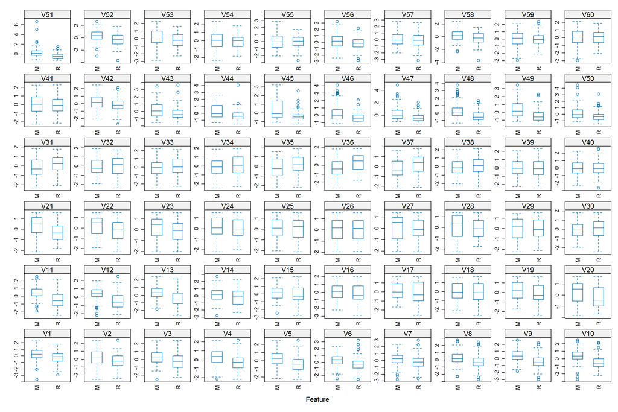

```r
##################################
# Formulating the box plots
##################################
featurePlot(x = EDA.Predictors.Numeric,
            y = EDA$Class,
            plot = "box",
            scales = list(x = list(relation="free", rot = 90),
                          y = list(relation="free")),
            adjust = 1.5,
            pch = "|")
```

## 1.5 Predictive Model Development and Hyperparameter Tuning

### 1.5.1 Support Vector Machine - Radial Basis Function Kernel - Manual Grid Search (SVM_R_MGS)

[Support Vector Machine](https://dl.acm.org/doi/10.1145/130385.130401) plots each observation in an N-dimensional space corresponding to the number of features in the data set and finds a hyperplane that maximally separates the different classes by a maximally large margin (which is defined as the distance between the hyperplane and the closest data points from each class). The algorithm applies kernel transformation by mapping non-linearly separable data using the similarities between the points in a high-dimensional feature space for improved discrimination.  
[Manual Grid Search](https://link.springer.com/book/10.1007/978-981-19-5170-1) involves the explicit selection of individual model hyperparameter values to be assessed as influenced by human domain background and experience. Based on these hyperparameter settings, the model is trained with the performance measures evaluated. This process is repeated with another set of values for the same hyperparameters until optimal accuracy is achieved, or the model has attained minimal error. While this process is practical in terms of computation power and time, it is highly dependent on human judgement.  
**[A]** The support vector machine (radial basis function kernel) model from the **kernlab** package was implemented through the **caret** package.  
**[B]** The model contains 2 hyperparameters:  
**[B.1]** sigma = sigma  
**[B.2]** C = cost  
**[C]** Performance of the applied manual grid search method for hyperparameter tuning is summarized as follows :  
**[C.1]** Final model configuration involves sigma=0.03000 and C=2  
**[C.2]** Cross-Validation AUROC = 0.96629  
**[C.3]** Test AUROC = 0.93780  
**[D]** The model does not allow for ranking of predictors in terms of variable importance.

**Code Chunk | Output**

```r
##################################
# Transforming factor predictors
# as required by the nature of the model
##################################
# Creating a local object
# for the train and test sets
##################################
PMA_PreModelling_Train_SVM_R <- as.data.frame(lapply(PMA_PreModelling_Train[,!names(PMA_PreModelling_Train) %in%
                                                                            c("Class")],
                                                   function(x) as.numeric(as.character(x))))
PMA_PreModelling_Train_SVM_R$Class <- PMA_PreModelling_Train$Class
dim(PMA_PreModelling_Train_SVM_R)
```

```
## [1] 167  61
```

```r
PMA_PreModelling_Test_SVM_R <- as.data.frame(lapply(PMA_PreModelling_Test[,!names(PMA_PreModelling_Test) %in%
                                                                          c("Class")],
                                                  function(x) as.numeric(as.character(x))))
PMA_PreModelling_Test_SVM_R$Class <- PMA_PreModelling_Test$Class
dim(PMA_PreModelling_Test_SVM_R)
```

```
## [1] 41 61
```

```r
##################################
# Creating consistent fold assignments
# for the 10-Fold Cross Validation process
##################################
set.seed(12345678)
KFold_Indices <- createFolds(PMA_PreModelling_Train_SVM_R$Class,
                             k = 10,
                             returnTrain=TRUE)
KFold_Control_RandomSearch <- trainControl(method="cv",
                              index=KFold_Indices,
                              summaryFunction = twoClassSummary,
                              classProbs = TRUE,
                              search = "random")

KFold_Control_GridSearch <- trainControl(method="cv",
                              index=KFold_Indices,
                              summaryFunction = twoClassSummary,
                              classProbs = TRUE)

##################################
# Setting the conditions
# for hyperparameter tuning
##################################
SVM_R_Grid = expand.grid(sigma = c(0.030, 0.025, 0.020, 0.015, 0.010, 0.005),
                       C = 2^(-2:9))

##################################
# Running the support vector machine (radial basis function kernel) model
# by setting the caret method to 'svmRadial'
##################################

##################################
# Using a manual grid search
##################################
set.seed(12345678)
SVM_R_Tune_GridSearch_Manual <- train(x = PMA_PreModelling_Train_SVM_R[,!names(PMA_PreModelling_Train_SVM_R) %in% c("Class")],
                 y = PMA_PreModelling_Train_SVM_R$Class,
                 method = "svmRadial",
                 tuneGrid = SVM_R_Grid,
                 metric = "ROC",
                 preProc = c("center", "scale"),
                 trControl = KFold_Control_GridSearch,
                 returnResamp = "all")

SVM_R_Tune_GridSearch_Manual$finalModel
```

```
## Support Vector Machine object of class "ksvm"
##
## SV type: C-svc  (classification)
##  parameter : cost C = 2
##
## Gaussian Radial Basis kernel function.
##  Hyperparameter : sigma =  0.03
##
## Number of Support Vectors : 156
##
## Objective Function Value : -54.7816
## Training error : 0
## Probability model included.
```

```r
SVM_R_Tune_GridSearch_Manual$results
```

```
##    sigma      C       ROC      Sens      Spec      ROCSD     SensSD     SpecSD
## 1  0.005   0.25 0.8260169 0.7888889 0.7321429 0.13266813 0.16101530 0.21179103
## 2  0.005   0.50 0.8414683 0.8333333 0.7303571 0.13145729 0.14103284 0.18412976
## 3  0.005   1.00 0.8714286 0.8777778 0.7696429 0.10662639 0.11049210 0.19351190
## 4  0.005   2.00 0.8863095 0.8888889 0.7964286 0.09551350 0.11712139 0.19852774
## 5  0.005   4.00 0.8880952 0.9111111 0.8089286 0.10012450 0.11475506 0.19652775
## 6  0.005   8.00 0.8938492 0.8888889 0.7964286 0.09055897 0.11712139 0.18675684
## 7  0.005  16.00 0.9109375 0.9000000 0.7821429 0.08273844 0.12227833 0.14526737
## 8  0.005  32.00 0.9151042 0.8652778 0.8214286 0.08203275 0.17198934 0.12371791
## 9  0.005  64.00 0.9151042 0.8652778 0.8214286 0.08203275 0.17198934 0.12371791
## 10 0.005 128.00 0.9151042 0.8763889 0.8214286 0.08203275 0.16927613 0.12371791
## 11 0.005 256.00 0.9151042 0.8986111 0.8214286 0.08203275 0.09756333 0.12371791
## 12 0.005 512.00 0.9151042 0.8652778 0.8071429 0.08203275 0.17198934 0.10806482
## 13 0.010   0.25 0.8458333 0.8222222 0.7196429 0.13137608 0.16728281 0.19742712
## 14 0.010   0.50 0.8684524 0.8444444 0.7821429 0.11588634 0.11944086 0.18706014
```

[output cut: 58 more lines]

```r
##################################
# Reporting the cross-validation results
# for the train set
##################################
(SVM_R_Train_GridSearch_Manual_ROCCurveAUC <- SVM_R_Tune_GridSearch_Manual$results[SVM_R_Tune_GridSearch_Manual$results$C==SVM_R_Tune_GridSearch_Manual$bestTune$C &
                                                                                     SVM_R_Tune_GridSearch_Manual$results$sigma==SVM_R_Tune_GridSearch_Manual$bestTune$sigma,
                                                                               c("ROC")])
```

```
## [1] 0.9662946
```

```r
##################################
# Independently evaluating the model
# on the test set
##################################
SVM_R_Test_GridSearch_Manual <- data.frame(SVM_R_Observed = PMA_PreModelling_Test_SVM_R$Class,
                      SVM_R_Predicted = predict(SVM_R_Tune_GridSearch_Manual,
                      PMA_PreModelling_Test_SVM_R[,!names(PMA_PreModelling_Test_SVM_R) %in% c("Class")],
                      type = "prob"))

SVM_R_Test_GridSearch_Manual
```

```
##    SVM_R_Observed SVM_R_Predicted.M SVM_R_Predicted.R
## 1               R       0.498313517       0.501686483
## 2               R       0.252823888       0.747176112
## 3               R       0.432002237       0.567997763
## 4               R       0.338372591       0.661627409
## 5               R       0.044367096       0.955632904
## 6               R       0.792956664       0.207043336
## 7               R       0.372759443       0.627240557
## 8               R       0.518259266       0.481740734
## 9               R       0.166319456       0.833680544
## 10              R       0.007429286       0.992570714
## 11              R       0.409778215       0.590221785
## 12              R       0.187868114       0.812131886
## 13              R       0.001983070       0.998016930
## 14              R       0.015027703       0.984972297
```

[output cut: 27 more lines]

```r
##################################
# Reporting the independent evaluation results
# for the test set
##################################
SVM_R_Test_GridSearch_Manual_ROC <- roc(response = SVM_R_Test_GridSearch_Manual$SVM_R_Observed,
             predictor = SVM_R_Test_GridSearch_Manual$SVM_R_Predicted.R,
             levels = rev(levels(SVM_R_Test_GridSearch_Manual$SVM_R_Observed)))

(SVM_R_Test_GridSearch_Manual_ROCCurveAUC <- auc(SVM_R_Test_GridSearch_Manual_ROC)[1])
```

```
## [1] 0.937799
```

### 1.5.2 Support Vector Machine - Radial Basis Function Kernel - Automated Grid Search (SVM_R_AGS)

[Support Vector Machine](https://dl.acm.org/doi/10.1145/130385.130401) plots each observation in an N-dimensional space corresponding to the number of features in the data set and finds a hyperplane that maximally separates the different classes by a maximally large margin (which is defined as the distance between the hyperplane and the closest data points from each class). The algorithm applies kernel transformation by mapping non-linearly separable data using the similarities between the points in a high-dimensional feature space for improved discrimination.  
[Automated Grid Search](https://link.springer.com/book/10.1007/978-981-19-5170-1) involves the selection of the range and interval of model hyperparameter values to be assessed based on the model default settings. Utilizing all the possible combinations of the hyperparameter values, the model is trained with the performance measures evaluated. This process is repeated with another set of values for the same hyperparameters until optimal accuracy is achieved, or the model has attained minimal error. While this process is extensive in terms of computation power and time, it is the most efficient method as there is the least possibility of missing out on an optimal solution for a model.  
**[A]** The support vector machine (radial basis function kernel) model from the **kernlab** package was implemented through the **caret** package.  
**[B]** The model contains 2 hyperparameters:  
**[B.1]** sigma = sigma  
**[B.2]** C = cost  
**[C]** Performance of the applied automated grid search method for hyperparameter tuning is summarized as follows :  
**[C.1]** Final model configuration involves sigma=0.01012 and C=8  
**[C.2]** Cross-Validation AUROC = 0.93514  
**[C.3]** Test AUROC = 0.91148  
**[D]** The model does not allow for ranking of predictors in terms of variable importance.

**Code Chunk | Output**

```r
##################################
# Using an automated grid search
##################################
set.seed(12345678)
SVM_R_Tune_GridSearch_Auto <- train(x = PMA_PreModelling_Train_SVM_R[,!names(PMA_PreModelling_Train_SVM_R) %in% c("Class")],
                 y = PMA_PreModelling_Train_SVM_R$Class,
                 method = "svmRadial",
                 tuneLength = 12,
                 metric = "ROC",
                 preProc = c("center", "scale"),
                 trControl = KFold_Control_GridSearch,
                 returnResamp = "all")

SVM_R_Tune_GridSearch_Auto$finalModel
```

```
## Support Vector Machine object of class "ksvm"
##
## SV type: C-svc  (classification)
##  parameter : cost C = 8
##
## Gaussian Radial Basis kernel function.
##  Hyperparameter : sigma =  0.0101286917816145
##
## Number of Support Vectors : 107
##
## Objective Function Value : -116.4213
## Training error : 0
## Probability model included.
```

```r
SVM_R_Tune_GridSearch_Auto$results
```

```
##         sigma      C       ROC      Sens      Spec      ROCSD    SensSD
## 1  0.01012869   0.25 0.8472222 0.8222222 0.7321429 0.13031954 0.1672828
## 2  0.01012869   0.50 0.8698413 0.8555556 0.7821429 0.11287340 0.1054093
## 3  0.01012869   1.00 0.9017857 0.8986111 0.7964286 0.08970483 0.1107343
## 4  0.01012869   2.00 0.9047867 0.9097222 0.8232143 0.09063022 0.1151373
## 5  0.01012869   4.00 0.9252232 0.9097222 0.7821429 0.08053464 0.1025335
## 6  0.01012869   8.00 0.9351438 0.8986111 0.8339286 0.07128847 0.1224972
## 7  0.01012869  16.00 0.9321925 0.9097222 0.8214286 0.06984564 0.1151373
## 8  0.01012869  32.00 0.9321925 0.8986111 0.8339286 0.06984564 0.1224972
## 9  0.01012869  64.00 0.9321925 0.9097222 0.8214286 0.06984564 0.1151373
## 10 0.01012869 128.00 0.9321925 0.9097222 0.8339286 0.06984564 0.1151373
## 11 0.01012869 256.00 0.9321925 0.8986111 0.8339286 0.06984564 0.1107343
## 12 0.01012869 512.00 0.9321925 0.8986111 0.8339286 0.06984564 0.1107343
##       SpecSD
## 1  0.2117910
## 2  0.1870601
## 3  0.1985277
## 4  0.2054132
## 5  0.1870601
## 6  0.1220020
## 7  0.1237179
## 8  0.1220020
## 9  0.1237179
## 10 0.1220020
## 11 0.1220020
## 12 0.1220020
```

```r
##################################
# Reporting the cross-validation results
# for the train set
##################################
(SVM_R_Train_GridSearch_Auto_ROCCurveAUC <- SVM_R_Tune_GridSearch_Auto$results[SVM_R_Tune_GridSearch_Auto$results$C==SVM_R_Tune_GridSearch_Auto$bestTune$C &
                                                                                 SVM_R_Tune_GridSearch_Auto$results$sigma==SVM_R_Tune_GridSearch_Auto$bestTune$sigma,
                                                                               c("ROC")])
```

```
## [1] 0.9351438
```

```r
##################################
# Independently evaluating the model
# on the test set
##################################
SVM_R_Test_GridSearch_Auto <- data.frame(SVM_R_Observed = PMA_PreModelling_Test_SVM_R$Class,
                      SVM_R_Predicted = predict(SVM_R_Tune_GridSearch_Auto,
                      PMA_PreModelling_Test_SVM_R[,!names(PMA_PreModelling_Test_SVM_R) %in% c("Class")],
                      type = "prob"))

SVM_R_Test_GridSearch_Auto
```

```
##    SVM_R_Observed SVM_R_Predicted.M SVM_R_Predicted.R
## 1               R       0.644520120       0.355479880
## 2               R       0.068227365       0.931772635
## 3               R       0.274246432       0.725753568
## 4               R       0.306557842       0.693442158
## 5               R       0.035774492       0.964225508
## 6               R       0.630076881       0.369923119
## 7               R       0.182377193       0.817622807
## 8               R       0.592301365       0.407698635
## 9               R       0.302447356       0.697552644
## 10              R       0.025172209       0.974827791
## 11              R       0.280726484       0.719273516
## 12              R       0.159681848       0.840318152
## 13              R       0.005997015       0.994002985
## 14              R       0.030660134       0.969339866
```

[output cut: 27 more lines]

```r
##################################
# Reporting the independent evaluation results
# for the test set
##################################
SVM_R_Test_GridSearch_Auto_ROC <- roc(response = SVM_R_Test_GridSearch_Auto$SVM_R_Observed,
             predictor = SVM_R_Test_GridSearch_Auto$SVM_R_Predicted.R,
             levels = rev(levels(SVM_R_Test_GridSearch_Auto$SVM_R_Observed)))

(SVM_R_Test_GridSearch_Auto_ROCCurveAUC <- auc(SVM_R_Test_GridSearch_Auto_ROC)[1])
```

```
## [1] 0.9114833
```

### 1.5.3 Support Vector Machine - Radial Basis Function Kernel - Automated Random Search (SVM_R_ARS)

[Support Vector Machine](https://dl.acm.org/doi/10.1145/130385.130401) plots each observation in an N-dimensional space corresponding to the number of features in the data set and finds a hyperplane that maximally separates the different classes by a maximally large margin (which is defined as the distance between the hyperplane and the closest data points from each class). The algorithm applies kernel transformation by mapping non-linearly separable data using the similarities between the points in a high-dimensional feature space for improved discrimination.  
[Automated Random Search](https://link.springer.com/book/10.1007/978-981-19-5170-1) involves the selection of the range and interval of model hyperparameter values to be assessed based on the model default settings. Utilizing random combinations of the hyperparameter values, the model is trained with the performance measures evaluated. This process is repeated with another set of values for the same hyperparameters until optimal accuracy is achieved, or the model has attained minimal error. This process might be reasonably effective in terms of computation power and time, but may miss on a few combinations which could have been optimal ones.  
**[A]** The support vector machine (radial basis function kernel) model from the **kernlab** package was implemented through the **caret** package.  
**[B]** The model contains 2 hyperparameters:  
**[B.1]** sigma = sigma  
**[B.2]** C = cost  
**[C]** Performance of the applied automated random search method for hyperparameter tuning is summarized as follows :  
**[C.1]** Final model configuration involves sigma=0.02458 and C=183  
**[C.2]** Cross-Validation AUROC = 0.96213  
**[C.3]** Test AUROC = 0.93541  
**[D]** The model does not allow for ranking of predictors in terms of variable importance.

**Code Chunk | Output**

```r
##################################
# Using an automated random search
##################################
set.seed(12345678)
SVM_R_Tune_RandomSearch_Auto <- train(x = PMA_PreModelling_Train_SVM_R[,!names(PMA_PreModelling_Train_SVM_R) %in% c("Class")],
                 y = PMA_PreModelling_Train_SVM_R$Class,
                 method = "svmRadial",
                 tuneLength = 30,
                 metric = "ROC",
                 preProc = c("center", "scale"),
                 trControl = KFold_Control_RandomSearch,
                 returnResamp = "all")

SVM_R_Tune_RandomSearch_Auto$finalModel
```

```
## Support Vector Machine object of class "ksvm"
##
## SV type: C-svc  (classification)
##  parameter : cost C = 183.359327063186
##
## Gaussian Radial Basis kernel function.
##  Hyperparameter : sigma =  0.0245815648934837
##
## Number of Support Vectors : 145
##
## Objective Function Value : -57.5767
## Training error : 0
## Probability model included.
```

```r
SVM_R_Tune_RandomSearch_Auto$results
```

```
##          sigma            C       ROC      Sens      Spec      ROCSD     SensSD
## 1  0.003062763   0.07968017 0.8188988 0.5736111 0.8357143 0.12762632 0.14404771
## 2  0.003161972 557.27174973 0.8962550 0.8555556 0.7803571 0.08481918 0.16604824
## 3  0.003197104  19.09397071 0.8890873 0.8888889 0.7446429 0.09068061 0.10475656
## 4  0.003260497 311.39561843 0.9031994 0.8666667 0.7785714 0.07868373 0.17213259
## 5  0.003720532   2.43055400 0.8789683 0.9111111 0.7964286 0.09924602 0.10210406
## 6  0.003771907   1.36632284 0.8684524 0.8666667 0.7946429 0.11078013 0.12614360
## 7  0.004808965   0.58526382 0.8428571 0.8444444 0.7428571 0.12813221 0.14054567
## 8  0.004911297   0.20061724 0.8218502 0.6763889 0.7839286 0.13322750 0.16744289
## 9  0.005629841   1.35019752 0.8930556 0.8777778 0.7964286 0.09020180 0.12227833
## 10 0.005642254 185.24975110 0.9180804 0.8875000 0.8214286 0.08155714 0.11720372
## 11 0.006545177   0.09296935 0.8190724 0.6069444 0.8232143 0.13421268 0.18239213
## 12 0.007471523  41.17996347 0.9240327 0.8875000 0.8214286 0.08203642 0.11720372
## 13 0.007619948   0.66682930 0.8696429 0.8666667 0.7821429 0.10902894 0.10210406
## 14 0.008007937 412.07218822 0.9226438 0.8875000 0.8214286 0.08071429 0.11720372
```

[output cut: 47 more lines]

```r
##################################
# Reporting the cross-validation results
# for the train set
##################################
(SVM_R_Train_RandomSearch_Auto_ROCCurveAUC <- SVM_R_Tune_RandomSearch_Auto$results[SVM_R_Tune_RandomSearch_Auto$results$C==SVM_R_Tune_RandomSearch_Auto$bestTune$C &
                                                                                     SVM_R_Tune_RandomSearch_Auto$results$sigma==SVM_R_Tune_RandomSearch_Auto$bestTune$sigma,
                                                                               c("ROC")])
```

```
## [1] 0.962128
```

```r
##################################
# Independently evaluating the model
# on the test set
##################################
SVM_R_Test_RandomSearch_Auto <- data.frame(SVM_R_Observed = PMA_PreModelling_Test_SVM_R$Class,
                      SVM_R_Predicted = predict(SVM_R_Tune_RandomSearch_Auto,
                      PMA_PreModelling_Test_SVM_R[,!names(PMA_PreModelling_Test_SVM_R) %in% c("Class")],
                      type = "prob"))

SVM_R_Test_RandomSearch_Auto
```

```
##    SVM_R_Observed SVM_R_Predicted.M SVM_R_Predicted.R
## 1               R      0.4461118516      0.5538881484
## 2               R      0.0917810626      0.9082189374
## 3               R      0.3003831045      0.6996168955
## 4               R      0.2113270453      0.7886729547
## 5               R      0.0110686706      0.9889313294
## 6               R      0.7937314777      0.2062685223
## 7               R      0.2302256584      0.7697743416
## 8               R      0.4654496465      0.5345503535
## 9               R      0.0718372374      0.9281627626
## 10              R      0.0017355436      0.9982644564
## 11              R      0.2759847540      0.7240152460
## 12              R      0.0883429855      0.9116570145
## 13              R      0.0003928833      0.9996071167
## 14              R      0.0033157653      0.9966842347
```

[output cut: 27 more lines]

```r
##################################
# Reporting the independent evaluation results
# for the test set
##################################
SVM_R_Test_RandomSearch_Auto_ROC <- roc(response = SVM_R_Test_RandomSearch_Auto$SVM_R_Observed,
             predictor = SVM_R_Test_RandomSearch_Auto$SVM_R_Predicted.R,
             levels = rev(levels(SVM_R_Test_RandomSearch_Auto$SVM_R_Observed)))

(SVM_R_Test_RandomSearch_Auto_ROCCurveAUC <- auc(SVM_R_Test_RandomSearch_Auto_ROC)[1])
```

```
## [1] 0.9354067
```

### 1.5.4 Regularized Discriminant Analysis - Manual Grid Search (RDA_MGS)

[Regularized Discriminant Analysis](https://www.tandfonline.com/doi/abs/10.1080/01621459.1989.10478752) serves as a compromise between Linear Discriminant Analysis (LDA) and Quadratic Discriminant Analysis (QDA). LDA uses Bayes’ rule to determine the posterior probability that an observation belongs to a certain class. Due to the normal assumption of LDA, the posterior is defined by a multivariate Gaussian whose covariance matrix is assumed to be identical for all classes. New points are classified by computing the discriminant function (the enumerator of the posterior probability) and returning the class with the maximal value. The discriminant variables can be obtained through eigen-decompositions of the within-class and between-class variance. QDA is a variant of LDA in which an individual covariance matrix is estimated for every class of observations. QDA is particularly useful if there is prior knowledge that individual classes exhibit distinct covariances. RDA introduces a regularization parameter that shrinks the separate covariance matrices of QDA towards a common LDA matrix. The parameter can take values from 0 (LDA) to 1 (QDA) and any value in between is a compromise between the two approaches, with the optimal hyperparameter value determined through cross-validation. Since RDA is a regularization technique, it is particularly useful when there are many features that are potentially correlated.  
[Manual Grid Search](https://link.springer.com/book/10.1007/978-981-19-5170-1) involves the explicit selection of individual model hyperparameter values to be assessed as influenced by human domain background and experience. Based on these hyperparameter settings, the model is trained with the performance measures evaluated. This process is repeated with another set of values for the same hyperparameters until optimal accuracy is achieved, or the model has attained minimal error. While this process is practical in terms of computation power and time, it is highly dependent on human judgement.  
**[A]** The regularized discriminant analysis model from the **klaR** package was implemented through the **caret** package.  
**[B]** The model contains 2 hyperparameters:  
**[B.1]** gamma = gamma  
**[B.2]** lambda = lambda  
**[C]** Performance of the applied manual grid search method for hyperparameter tuning is summarized as follows :  
**[C.1]** Final model configuration involves gamma=0.60 and lambda=0.20  
**[C.2]** Cross-Validation AUROC = 0.91150  
**[C.3]** Test AUROC = 0.87560  
**[D]** The model does not allow for ranking of predictors in terms of variable importance.

**Code Chunk | Output**

```r
##################################
# Creating a local object
# for the train and test sets
##################################
PMA_PreModelling_Train_RDA <- PMA_PreModelling_Train
PMA_PreModelling_Test_RDA <- PMA_PreModelling_Test

##################################
# Creating consistent fold assignments
# for the 10-Fold Cross Validation process
##################################
set.seed(12345678)
KFold_Indices <- createFolds(PMA_PreModelling_Train_RDA$Class,
                             k = 10,
                             returnTrain=TRUE)

KFold_Control_RandomSearch <- trainControl(method="cv",
                              index=KFold_Indices,
                              summaryFunction = twoClassSummary,
                              classProbs = TRUE,
                              search = "random")

KFold_Control_GridSearch <- trainControl(method="cv",
                              index=KFold_Indices,
                              summaryFunction = twoClassSummary,
                              classProbs = TRUE)

##################################
# Setting the conditions
# for hyperparameter tuning
##################################
RDA_Grid = expand.grid(gamma = seq(0,1,0.20),
                       lambda = seq(0,1,0.20))

##################################
# Running the regularized discriminant analysis model
# by setting the caret method to 'rda'
##################################

##################################
# Using a manual grid search
##################################
set.seed(12345678)
RDA_Tune_GridSearch_Manual <- train(x = PMA_PreModelling_Train_RDA[,!names(PMA_PreModelling_Train_RDA) %in% c("Class")],
                 y = PMA_PreModelling_Train_RDA$Class,
                 method = "rda",
                 tuneGrid = RDA_Grid,
                 metric = "ROC",
                 trControl = KFold_Control_GridSearch,
                 returnResamp = "all")

RDA_Tune_GridSearch_Manual$finalModel
```

```
## Call:
## rda.default(x = x, grouping = y, gamma = param$gamma, lambda = param$lambda,
##     returnResamp = "all")
##
## Regularization parameters:
##  gamma lambda
##    0.6    0.2
##
## Prior probabilities of groups:
##         M         R
## 0.5329341 0.4670659
##
## Misclassification rate:
##        apparent: 1.198 %
```

```r
RDA_Tune_GridSearch_Manual$results
```

```
##    gamma lambda       ROC      Sens      Spec      ROCSD     SensSD    SpecSD
## 1    0.0    0.0 0.7171627 0.9222222 0.4571429 0.06867241 0.07499428 0.1733768
## 2    0.0    0.2 0.8133681 0.8444444 0.6678571 0.08674264 0.10734353 0.1307358
## 3    0.0    0.4 0.8363343 0.8222222 0.6803571 0.08956975 0.14054567 0.1025642
## 4    0.0    0.6 0.8492063 0.8222222 0.6785714 0.10624090 0.14054567 0.1240040
## 5    0.0    0.8 0.8196429 0.8333333 0.7267857 0.14048419 0.14103284 0.1925207
## 6    0.0    1.0 0.7682540 0.8000000 0.6750000 0.16285642 0.17213259 0.1911817
## 7    0.2    0.0 0.8772569 0.8777778 0.7339286 0.09411413 0.11049210 0.1905599
## 8    0.2    0.2 0.8867560 0.8333333 0.7714286 0.07884393 0.10798059 0.1944890
## 9    0.2    0.4 0.8819692 0.8222222 0.7553571 0.07297162 0.13042087 0.1653969
## 10   0.2    0.6 0.8773810 0.8333333 0.7821429 0.08398065 0.14103284 0.1189881
## 11   0.2    0.8 0.8648810 0.8444444 0.7446429 0.10567719 0.14998857 0.1656110
## 12   0.2    1.0 0.8486111 0.8666667 0.7428571 0.12071166 0.14628458 0.1897680
## 13   0.4    0.0 0.9031994 0.8666667 0.8250000 0.08263177 0.08764563 0.1787301
## 14   0.4    0.2 0.8970486 0.8444444 0.8232143 0.07794668 0.10734353 0.1461549
```

[output cut: 22 more lines]

```r
##################################
# Reporting the cross-validation results
# for the train set
##################################
(RDA_Train_GridSearch_Manual_ROCCurveAUC <- RDA_Tune_GridSearch_Manual$results[RDA_Tune_GridSearch_Manual$results$gamma==RDA_Tune_GridSearch_Manual$bestTune$gamma &
                                                                                 RDA_Tune_GridSearch_Manual$results$lambda==RDA_Tune_GridSearch_Manual$bestTune$lambda,
                                                                               c("ROC")])
```

```
## [1] 0.9115079
```

```r
##################################
# Independently evaluating the model
# on the test set
##################################
RDA_Test_GridSearch_Manual <- data.frame(RDA_Observed = PMA_PreModelling_Test_RDA$Class,
                      RDA_Predicted = predict(RDA_Tune_GridSearch_Manual,
                      PMA_PreModelling_Test_RDA[,!names(PMA_PreModelling_Test_RDA) %in% c("Class")],
                      type = "prob"))

RDA_Test_GridSearch_Manual
```

```
##    RDA_Observed RDA_Predicted.M RDA_Predicted.R
## 1             R    9.939995e-01    6.000456e-03
## 2             R    8.730765e-02    9.126924e-01
## 3             R    3.181359e-02    9.681864e-01
## 4             R    1.527510e-01    8.472490e-01
## 5             R    2.466817e-03    9.975332e-01
## 6             R    9.772080e-01    2.279197e-02
## 7             R    9.486356e-01    5.136444e-02
## 8             R    8.394090e-01    1.605910e-01
## 9             R    1.672424e-01    8.327576e-01
## 10            R    1.587608e-06    9.999984e-01
## 11            R    1.833434e-01    8.166566e-01
## 12            R    3.039097e-02    9.696090e-01
## 13            R    2.978790e-04    9.997021e-01
## 14            R    4.653232e-03    9.953468e-01
```

[output cut: 27 more lines]

```r
##################################
# Reporting the independent evaluation results
# for the test set
##################################
RDA_Test_GridSearch_Manual_ROC <- roc(response = RDA_Test_GridSearch_Manual$RDA_Observed,
             predictor = RDA_Test_GridSearch_Manual$RDA_Predicted.R,
             levels = rev(levels(RDA_Test_GridSearch_Manual$RDA_Observed)))

(RDA_Test_GridSearch_Manual_ROCCurveAUC <- auc(RDA_Test_GridSearch_Manual_ROC)[1])
```

```
## [1] 0.8755981
```

### 1.5.5 Regularized Discriminant Analysis - Automated Grid Search (RDA_AGS)

[Regularized Discriminant Analysis](https://www.tandfonline.com/doi/abs/10.1080/01621459.1989.10478752) serves as a compromise between Linear Discriminant Analysis (LDA) and Quadratic Discriminant Analysis (QDA). LDA uses Bayes’ rule to determine the posterior probability that an observation belongs to a certain class. Due to the normal assumption of LDA, the posterior is defined by a multivariate Gaussian whose covariance matrix is assumed to be identical for all classes. New points are classified by computing the discriminant function (the enumerator of the posterior probability) and returning the class with the maximal value. The discriminant variables can be obtained through eigen-decompositions of the within-class and between-class variance. QDA is a variant of LDA in which an individual covariance matrix is estimated for every class of observations. QDA is particularly useful if there is prior knowledge that individual classes exhibit distinct covariances. RDA introduces a regularization parameter that shrinks the separate covariance matrices of QDA towards a common LDA matrix. The parameter can take values from 0 (LDA) to 1 (QDA) and any value in between is a compromise between the two approaches, with the optimal hyperparameter value determined through cross-validation. Since RDA is a regularization technique, it is particularly useful when there are many features that are potentially correlated.  
[Automated Grid Search](https://link.springer.com/book/10.1007/978-981-19-5170-1) involves the selection of the range and interval of model hyperparameter values to be assessed based on the model default settings. Utilizing all the possible combinations of the hyperparameter values, the model is trained with the performance measures evaluated. This process is repeated with another set of values for the same hyperparameters until optimal accuracy is achieved, or the model has attained minimal error. While this process is extensive in terms of computation power and time, it is the most efficient method as there is the least possibility of missing out on an optimal solution for a model.  
**[A]** The regularized discriminant analysis model from the **klaR** package was implemented through the **caret** package.  
**[B]** The model contains 2 hyperparameters:  
**[B.1]** gamma = gamma  
**[B.2]** lambda = lambda  
**[C]** Performance of the applied automated grid search method for hyperparameter tuning is summarized as follows :  
**[C.1]** Final model configuration involves gamma=0.57 and lambda=0.14  
**[C.2]** Cross-Validation AUROC = 0.91014  
**[C.3]** Test AUROC = 0.87081  
**[D]** The model does not allow for ranking of predictors in terms of variable importance.

**Code Chunk | Output**

```r
##################################
# Using an automated grid search
##################################
set.seed(12345678)
RDA_Tune_GridSearch_Auto <- train(x = PMA_PreModelling_Train_RDA[,!names(PMA_PreModelling_Train_RDA) %in% c("Class")],
                 y = PMA_PreModelling_Train_RDA$Class,
                 method = "rda",
                 tuneLength = 8,
                 metric = "ROC",
                 trControl = KFold_Control_GridSearch,
                 returnResamp = "all")

RDA_Tune_GridSearch_Auto$finalModel
```

```
## Call:
## rda.default(x = x, grouping = y, gamma = param$gamma, lambda = param$lambda,
##     returnResamp = "all")
##
## Regularization parameters:
##     gamma    lambda
## 0.5714286 0.1428571
##
## Prior probabilities of groups:
##         M         R
## 0.5329341 0.4670659
##
## Misclassification rate:
##        apparent: 1.198 %
```

```r
RDA_Tune_GridSearch_Auto$results
```

```
##        gamma    lambda       ROC      Sens      Spec      ROCSD     SensSD
## 1  0.0000000 0.0000000 0.7171627 0.9222222 0.4571429 0.06867241 0.07499428
## 2  0.0000000 0.1428571 0.8037698 0.8444444 0.6303571 0.08966800 0.10734353
## 3  0.0000000 0.2857143 0.8246776 0.8555556 0.6928571 0.08393174 0.10540926
## 4  0.0000000 0.4285714 0.8349454 0.8222222 0.6803571 0.08996755 0.14054567
## 5  0.0000000 0.5714286 0.8535714 0.8222222 0.6928571 0.09877685 0.14054567
## 6  0.0000000 0.7142857 0.8442460 0.8444444 0.7160714 0.10832942 0.14054567
## 7  0.0000000 0.8571429 0.8033730 0.8333333 0.6982143 0.15380205 0.14103284
## 8  0.0000000 1.0000000 0.7682540 0.8000000 0.6750000 0.16285642 0.17213259
## 9  0.1428571 0.0000000 0.8730903 0.8777778 0.7339286 0.09736862 0.11049210
## 10 0.1428571 0.1428571 0.8750744 0.8666667 0.7321429 0.07161015 0.11475506
## 11 0.1428571 0.2857143 0.8792163 0.8444444 0.7696429 0.07041525 0.13042087
## 12 0.1428571 0.4285714 0.8776042 0.8333333 0.7678571 0.07485983 0.13094570
## 13 0.1428571 0.5714286 0.8716270 0.8111111 0.7428571 0.08441315 0.13907395
## 14 0.1428571 0.7142857 0.8601190 0.8444444 0.7821429 0.09937926 0.13042087
```

[output cut: 115 more lines]

```r
##################################
# Reporting the cross-validation results
# for the train set
##################################
(RDA_Train_GridSearch_Auto_ROCCurveAUC <- RDA_Tune_GridSearch_Auto$results[RDA_Tune_GridSearch_Auto$results$gamma==RDA_Tune_GridSearch_Auto$bestTune$gamma &
                                                                             RDA_Tune_GridSearch_Auto$results$lambda==RDA_Tune_GridSearch_Auto$bestTune$lambda,
                                                                               c("ROC")])
```

```
## [1] 0.9101438
```

```r
##################################
# Independently evaluating the model
# on the test set
##################################
RDA_Test_GridSearch_Auto <- data.frame(RDA_Observed = PMA_PreModelling_Test_RDA$Class,
                      RDA_Predicted = predict(RDA_Tune_GridSearch_Auto,
                      PMA_PreModelling_Test_RDA[,!names(PMA_PreModelling_Test_RDA) %in% c("Class")],
                      type = "prob"))

RDA_Test_GridSearch_Auto
```

```
##    RDA_Observed RDA_Predicted.M RDA_Predicted.R
## 1             R    9.973229e-01    2.677145e-03
## 2             R    6.705582e-02    9.329442e-01
## 3             R    1.573949e-02    9.842605e-01
## 4             R    1.929045e-01    8.070955e-01
## 5             R    1.876099e-03    9.981239e-01
## 6             R    9.861147e-01    1.388529e-02
## 7             R    9.626076e-01    3.739240e-02
## 8             R    8.787244e-01    1.212756e-01
## 9             R    1.764799e-01    8.235201e-01
## 10            R    9.506597e-07    9.999990e-01
## 11            R    1.250982e-01    8.749018e-01
## 12            R    2.167116e-02    9.783288e-01
## 13            R    3.972024e-04    9.996028e-01
## 14            R    5.146713e-03    9.948533e-01
```

[output cut: 27 more lines]

```r
##################################
# Reporting the independent evaluation results
# for the test set
##################################
RDA_Test_GridSearch_Auto_ROC <- roc(response = RDA_Test_GridSearch_Auto$RDA_Observed,
             predictor = RDA_Test_GridSearch_Auto$RDA_Predicted.R,
             levels = rev(levels(RDA_Test_GridSearch_Auto$RDA_Observed)))

(RDA_Test_GridSearch_Auto_ROCCurveAUC <- auc(RDA_Test_GridSearch_Auto_ROC)[1])
```

```
## [1] 0.8708134
```

### 1.5.6 Regularized Discriminant Analysis - Automated Random Search (RDA_ARS)

[Regularized Discriminant Analysis](https://www.tandfonline.com/doi/abs/10.1080/01621459.1989.10478752) serves as a compromise between Linear Discriminant Analysis (LDA) and Quadratic Discriminant Analysis (QDA). LDA uses Bayes’ rule to determine the posterior probability that an observation belongs to a certain class. Due to the normal assumption of LDA, the posterior is defined by a multivariate Gaussian whose covariance matrix is assumed to be identical for all classes. New points are classified by computing the discriminant function (the enumerator of the posterior probability) and returning the class with the maximal value. The discriminant variables can be obtained through eigen-decompositions of the within-class and between-class variance. QDA is a variant of LDA in which an individual covariance matrix is estimated for every class of observations. QDA is particularly useful if there is prior knowledge that individual classes exhibit distinct covariances. Regularized Discriminant Analysis (RDA) introduces a regularization parameter that shrinks the separate covariance matrices of QDA towards a common LDA matrix. The parameter can take values from 0 (LDA) to 1 (QDA) and any value in between is a compromise between the two approaches, with the optimal hyperparameter value determined through cross-validation. Since RDA is a regularization technique, it is particularly useful when there are many features that are potentially correlated.  
[Automated Random Search](https://link.springer.com/book/10.1007/978-981-19-5170-1) involves the selection of the range and interval of model hyperparameter values to be assessed based on the model default settings. Utilizing random combinations of the hyperparameter values, the model is trained with the performance measures evaluated. This process is repeated with another set of values for the same hyperparameters until optimal accuracy is achieved, or the model has attained minimal error. This process might be reasonably effective in terms of computation power and time, but may miss on a few combinations which could have been optimal ones.  
**[A]** The regularized discriminant analysis model from the **klaR** package was implemented through the **caret** package.  
**[B]** The model contains 2 hyperparameters:  
**[B.1]** gamma = gamma  
**[B.2]** lambda = lambda  
**[C]** Performance of the applied automated random search method for hyperparameter tuning is summarized as follows :  
**[C.1]** Final model configuration involves gamma=0.48 and lambda=0.09  
**[C.2]** Cross-Validation AUROC = 0.90578  
**[C.3]** Test AUROC = 0.861244  
**[D]** The model does not allow for ranking of predictors in terms of variable importance.

**Code Chunk | Output**

```r
##################################
# Using an automated random search
##################################
set.seed(12345678)
RDA_Tune_RandomSearch_Auto <- train(x = PMA_PreModelling_Train_RDA[,!names(PMA_PreModelling_Train_RDA) %in% c("Class")],
                 y = PMA_PreModelling_Train_RDA$Class,
                 method = "rda",
                 tuneLength = 36,
                 metric = "ROC",
                 trControl = KFold_Control_RandomSearch,
                 returnResamp = "all")

RDA_Tune_RandomSearch_Auto$finalModel
```

```
## Call:
## rda.default(x = x, grouping = y, gamma = param$gamma, lambda = param$lambda,
##     returnResamp = "all")
##
## Regularization parameters:
##      gamma     lambda
## 0.47910538 0.09509243
##
## Prior probabilities of groups:
##         M         R
## 0.5329341 0.4670659
##
## Misclassification rate:
##        apparent: 0.599 %
```

```r
RDA_Tune_RandomSearch_Auto$results
```

```
##          gamma      lambda       ROC      Sens      Spec      ROCSD     SensSD
## 1  0.008678354 0.422683378 0.8468502 0.8222222 0.6785714 0.08719860 0.14054567
## 2  0.063090573 0.159730318 0.8601935 0.8444444 0.6928571 0.06592393 0.11944086
## 3  0.092448982 0.851543210 0.8541667 0.8444444 0.7535714 0.10672665 0.13042087
## 4  0.224852071 0.014492429 0.8857639 0.8666667 0.7464286 0.09217891 0.10210406
## 5  0.225922084 0.240498578 0.8839534 0.8333333 0.7839286 0.07936822 0.10798059
## 6  0.242685425 0.479121222 0.8843502 0.8333333 0.7839286 0.07331041 0.13094570
## 7  0.285900684 0.818685511 0.8692460 0.8444444 0.7446429 0.10440292 0.14998857
## 8  0.299823386 0.296154688 0.8926835 0.8333333 0.7964286 0.07517150 0.13094570
## 9  0.309769555 0.501567030 0.8905010 0.8444444 0.7964286 0.07483025 0.13042087
## 10 0.371572583 0.530818735 0.8918651 0.8555556 0.8089286 0.07707935 0.14861039
## 11 0.389756622 0.291965252 0.8952629 0.8444444 0.8232143 0.07455911 0.10734353
## 12 0.398705438 0.020711658 0.9004216 0.8666667 0.8250000 0.08738713 0.08764563
## 13 0.398780852 0.126081060 0.8986359 0.8555556 0.8375000 0.08278481 0.09147473
## 14 0.404947380 0.001431841 0.9018105 0.8666667 0.8250000 0.08480293 0.08764563
```

[output cut: 59 more lines]

```r
##################################
# Reporting the cross-validation results
# for the train set
##################################
(RDA_Train_RandomSearch_Auto_ROCCurveAUC <- RDA_Tune_RandomSearch_Auto$results[RDA_Tune_RandomSearch_Auto$results$gamma==RDA_Tune_RandomSearch_Auto$bestTune$gamma &
                                                                                 RDA_Tune_RandomSearch_Auto$results$lambda==RDA_Tune_RandomSearch_Auto$bestTune$lambda,
                                                                               c("ROC")])
```

```
## [1] 0.9057788
```

```r
##################################
# Independently evaluating the model
# on the test set
##################################
RDA_Test_RandomSearch_Auto <- data.frame(RDA_Observed = PMA_PreModelling_Test_RDA$Class,
                      RDA_Predicted = predict(RDA_Tune_RandomSearch_Auto,
                      PMA_PreModelling_Test_RDA[,!names(PMA_PreModelling_Test_RDA) %in% c("Class")],
                      type = "prob"))

RDA_Test_RandomSearch_Auto
```

```
##    RDA_Observed RDA_Predicted.M RDA_Predicted.R
## 1             R    9.996342e-01    3.657658e-04
## 2             R    5.444014e-02    9.455599e-01
## 3             R    2.402096e-03    9.975979e-01
## 4             R    3.138262e-01    6.861738e-01
## 5             R    1.116578e-03    9.988834e-01
## 6             R    9.916533e-01    8.346719e-03
## 7             R    9.595638e-01    4.043622e-02
## 8             R    9.431910e-01    5.680897e-02
## 9             R    2.228901e-01    7.771099e-01
## 10            R    5.857581e-07    9.999994e-01
## 11            R    4.288120e-02    9.571188e-01
## 12            R    9.111884e-03    9.908881e-01
## 13            R    1.101115e-03    9.988989e-01
## 14            R    6.469385e-03    9.935306e-01
```

[output cut: 27 more lines]

```r
##################################
# Reporting the independent evaluation results
# for the test set
##################################
RDA_Test_RandomSearch_Auto_ROC <- roc(response = RDA_Test_RandomSearch_Auto$RDA_Observed,
             predictor = RDA_Test_RandomSearch_Auto$RDA_Predicted.R,
             levels = rev(levels(RDA_Test_RandomSearch_Auto$RDA_Observed)))

(RDA_Test_RandomSearch_Auto_ROCCurveAUC <- auc(RDA_Test_RandomSearch_Auto_ROC)[1])
```

```
## [1] 0.861244
```

## 1.6 Consolidated Findings

**Code Chunk | Output**

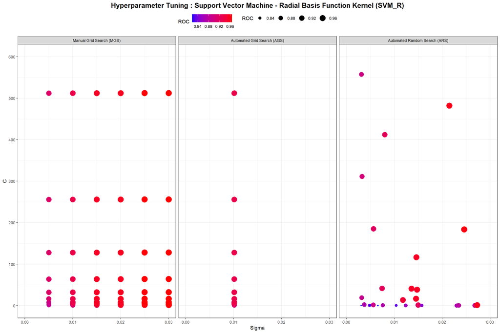

```r
##################################
# Consolidating all results
# from the evaluated hyperparameter tuning methods
# for Support Vector Machine - Radial Basis Function Kernel (SVM_R)
##################################
SVM_R_Tune_GridSearch_Manual_ROC <- SVM_R_Tune_GridSearch_Manual$results
SVM_R_Tune_GridSearch_Auto_ROC   <- SVM_R_Tune_GridSearch_Auto$results
SVM_R_Tune_RandomSearch_Auto_ROC <- SVM_R_Tune_RandomSearch_Auto$results

SVM_R_Tune_All <- as.data.frame(rbind(SVM_R_Tune_GridSearch_Manual_ROC,
                        SVM_R_Tune_GridSearch_Auto_ROC,
                        SVM_R_Tune_RandomSearch_Auto_ROC))

SVM_R_Tune_All$Method <- c(rep("Manual Grid Search (MGS)",nrow(SVM_R_Tune_GridSearch_Manual_ROC)),
                           rep("Automated Grid Search (AGS)",nrow(SVM_R_Tune_GridSearch_Auto_ROC)),
                           rep("Automated Random Search (ARS)",nrow(SVM_R_Tune_RandomSearch_Auto_ROC)))

SVM_R_Tune_All$Method <- factor(SVM_R_Tune_All$Method,
                                levels=c("Manual Grid Search (MGS)",
                                         "Automated Grid Search (AGS)",
                                         "Automated Random Search (ARS)"))

##################################
# Plotting all results
# from the evaluated hyperparameter tuning methods
##################################
ggplot(SVM_R_Tune_All, aes(x=sigma, y=C, color=ROC, size= ROC)) +
        geom_point() +
        scale_color_gradient(low="blue", high="red") +
        theme_bw() +
        facet_grid(. ~ Method) +
        scale_x_continuous(name="Sigma", limits=c(0,0.03),breaks=seq(0,0.03,by=0.01)) +
        scale_y_continuous(name="C", limits=c(0,600),breaks=seq(0,600,by=100)) +
        theme(legend.position="top",
              plot.title=element_text(color="black",size=15,face="bold",hjust=0.50)) +
  ggtitle("Hyperparameter Tuning : Support Vector Machine - Radial Basis Function Kernel (SVM_R)")
```

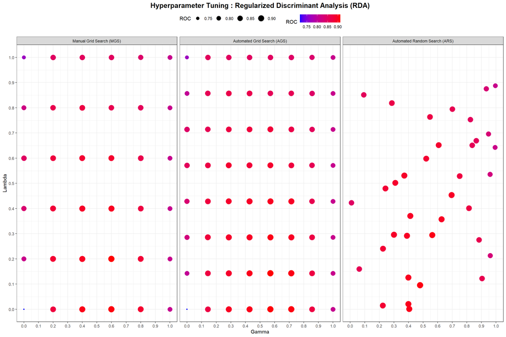

```r
##################################
# Consolidating all results
# from the evaluated hyperparameter tuning methods
# for Regularized Discriminant Analysis (RDA)
##################################
RDA_Tune_GridSearch_Manual_ROC <- RDA_Tune_GridSearch_Manual$results
RDA_Tune_GridSearch_Auto_ROC   <- RDA_Tune_GridSearch_Auto$results
RDA_Tune_RandomSearch_Auto_ROC <- RDA_Tune_RandomSearch_Auto$results

RDA_Tune_All <- as.data.frame(rbind(RDA_Tune_GridSearch_Manual_ROC,
                        RDA_Tune_GridSearch_Auto_ROC,
                        RDA_Tune_RandomSearch_Auto_ROC))

RDA_Tune_All$Method <- c(rep("Manual Grid Search (MGS)",nrow(RDA_Tune_GridSearch_Manual_ROC)),
                           rep("Automated Grid Search (AGS)",nrow(RDA_Tune_GridSearch_Auto_ROC)),
                           rep("Automated Random Search (ARS)",nrow(RDA_Tune_RandomSearch_Auto_ROC)))

RDA_Tune_All$Method <- factor(RDA_Tune_All$Method,
                                levels=c("Manual Grid Search (MGS)",
                                         "Automated Grid Search (AGS)",
                                         "Automated Random Search (ARS)"))

##################################
# Plotting all results
# from the evaluated hyperparameter tuning methods
##################################
ggplot(RDA_Tune_All, aes(x=gamma, y=lambda, color=ROC, size= ROC)) +
        geom_point() +
        scale_color_gradient(low="blue", high="red") +
        theme_bw() +
        facet_grid(. ~ Method) +
        scale_x_continuous(name="Gamma", limits=c(0,1),breaks=seq(0,1,by=0.10)) +
        scale_y_continuous(name="Lambda", limits=c(0,1),breaks=seq(0,1,by=0.10)) +
        theme(legend.position="top",
              plot.title=element_text(color="black",size=15,face="bold",hjust=0.50)) +
  ggtitle("Hyperparameter Tuning : Regularized Discriminant Analysis (RDA)")
```

```r
##################################
# Consolidating all evaluation results
# for the train and test sets
# using the AUROC metric
##################################
Model <- c('SVM_R_MGS','SVM_R_AGS','SVM_R_ARS','RDA_MGS','RDA_AGS','RDA_ARS',
           'SVM_R_MGS','SVM_R_AGS','SVM_R_ARS','RDA_MGS','RDA_AGS','RDA_ARS')

Set <- c(rep('Cross-Validation',6),rep('Test',6))

ROCCurveAUC <- c(SVM_R_Train_GridSearch_Manual_ROCCurveAUC,
                 SVM_R_Train_GridSearch_Auto_ROCCurveAUC,
                 SVM_R_Train_RandomSearch_Auto_ROCCurveAUC,
                 RDA_Train_GridSearch_Manual_ROCCurveAUC,
                 RDA_Train_GridSearch_Auto_ROCCurveAUC,
                 RDA_Train_RandomSearch_Auto_ROCCurveAUC,
                 SVM_R_Test_GridSearch_Manual_ROCCurveAUC,
                 SVM_R_Test_GridSearch_Auto_ROCCurveAUC,
                 SVM_R_Test_RandomSearch_Auto_ROCCurveAUC,
                 RDA_Test_GridSearch_Manual_ROCCurveAUC,
                 RDA_Test_GridSearch_Auto_ROCCurveAUC,
                 RDA_Test_RandomSearch_Auto_ROCCurveAUC)

ROCCurveAUC_Summary <- as.data.frame(cbind(Model,Set,ROCCurveAUC))

ROCCurveAUC_Summary$ROCCurveAUC <- as.numeric(as.character(ROCCurveAUC_Summary$ROCCurveAUC))
ROCCurveAUC_Summary$Set <- factor(ROCCurveAUC_Summary$Set,
                                        levels = c("Cross-Validation",
                                                   "Test"))
ROCCurveAUC_Summary$Model <- factor(ROCCurveAUC_Summary$Model,
                                        levels = c('SVM_R_MGS',
                                                   'SVM_R_AGS',
                                                   'SVM_R_ARS',
                                                   'RDA_MGS',
                                                   'RDA_AGS',
                                                   'RDA_ARS'))

print(ROCCurveAUC_Summary, row.names=FALSE)
```

```
##      Model              Set ROCCurveAUC
##  SVM_R_MGS Cross-Validation   0.9662946
##  SVM_R_AGS Cross-Validation   0.9351438
##  SVM_R_ARS Cross-Validation   0.9621280
##    RDA_MGS Cross-Validation   0.9115079
##    RDA_AGS Cross-Validation   0.9101438
##    RDA_ARS Cross-Validation   0.9057788
##  SVM_R_MGS             Test   0.9377990
##  SVM_R_AGS             Test   0.9114833
##  SVM_R_ARS             Test   0.9354067
##    RDA_MGS             Test   0.8755981
##    RDA_AGS             Test   0.8708134
##    RDA_ARS             Test   0.8612440
```

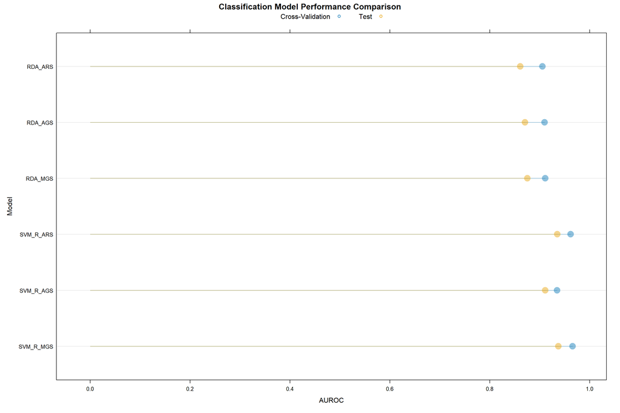

```r
(ROCCurveAUC_Plot <- dotplot(Model ~ ROCCurveAUC,
                           data = ROCCurveAUC_Summary,
                           groups = Set,
                           main = "Classification Model Performance Comparison",
                           ylab = "Model",
                           xlab = "AUROC",
                           auto.key = list(adj=1, space="top", columns=2),
                           type=c("p", "h"),
                           origin = 0,
                           alpha = 0.45,
                           pch = 16,
                           cex = 2))
```

```r
##################################
# Consolidating the resampling results
# for the candidate models
##################################
(OverallResampling <- resamples(list(SVM_R_MGS = SVM_R_Tune_GridSearch_Manual,
                                    SVM_R_AGS = SVM_R_Tune_GridSearch_Auto,
                                    SVM_R_ARS = SVM_R_Tune_RandomSearch_Auto,
                                    RDA_MGS = RDA_Tune_GridSearch_Manual,
                                    RDA_AGS = RDA_Tune_GridSearch_Auto,
                                    RDA_ARS = RDA_Tune_RandomSearch_Auto)))
```

[output not shown]

```r
summary(OverallResampling)
```

```
##
## Call:
## summary.resamples(object = OverallResampling)
##
## Models: SVM_R_MGS, SVM_R_AGS, SVM_R_ARS, RDA_MGS, RDA_AGS, RDA_ARS
## Number of resamples: 10
##
## ROC
##                Min.   1st Qu.    Median      Mean   3rd Qu. Max. NA's
## SVM_R_MGS 0.9027778 0.9409722 0.9781746 0.9662946 0.9960938    1    0
## SVM_R_AGS 0.8055556 0.8993056 0.9543651 0.9351438 0.9960938    1    0
## SVM_R_ARS 0.9027778 0.9201389 0.9781746 0.9621280 0.9960938    1    0
## RDA_MGS   0.7638889 0.8680556 0.9126984 0.9115079 0.9811508    1    0
## RDA_AGS   0.7638889 0.8680556 0.9206349 0.9101438 0.9776786    1    0
## RDA_ARS   0.7638889 0.8645833 0.9236111 0.9057788 0.9722222    1    0
##
## Sens
##                Min.   1st Qu.    Median      Mean   3rd Qu. Max. NA's
## SVM_R_MGS 0.7777778 0.8784722 1.0000000 0.9319444 1.0000000    1    0
## SVM_R_AGS 0.6666667 0.8020833 0.9444444 0.8986111 1.0000000    1    0
## SVM_R_ARS 0.7777778 0.9166667 1.0000000 0.9541667 1.0000000    1    0
## RDA_MGS   0.6666667 0.7777778 0.8888889 0.8555556 0.8888889    1    0
## RDA_AGS   0.6666667 0.7777778 0.8888889 0.8555556 0.8888889    1    0
## RDA_ARS   0.6666667 0.7777778 0.8333333 0.8444444 0.8888889    1    0
##
## Spec
##            Min.   1st Qu.    Median      Mean 3rd Qu. Max. NA's
## SVM_R_MGS 0.750 0.8616071 0.8750000 0.8857143 0.96875    1    0
## SVM_R_AGS 0.625 0.7500000 0.8750000 0.8339286 0.87500    1    0
## SVM_R_ARS 0.750 0.7767857 0.8750000 0.8607143 0.87500    1    0
## RDA_MGS   0.625 0.7500000 0.8660714 0.8232143 0.87500    1    0
## RDA_AGS   0.625 0.7767857 0.8750000 0.8357143 0.87500    1    0
## RDA_ARS   0.625 0.7812500 0.8750000 0.8500000 0.96875    1    0
```

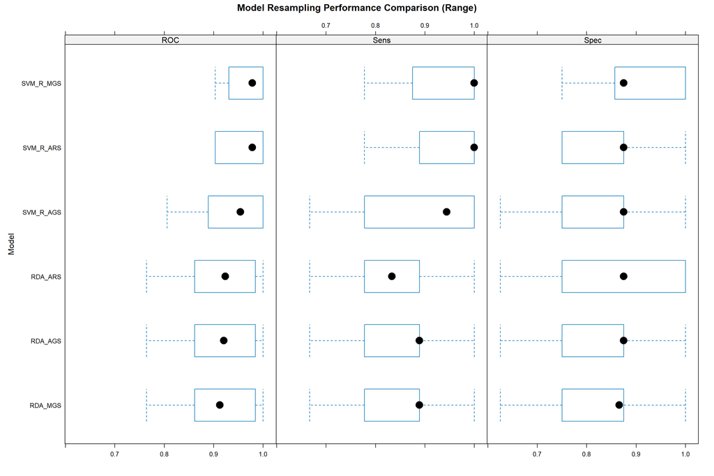

```r
##################################
# Exploring the resampling results
##################################
bwplot(OverallResampling,
       main = "Model Resampling Performance Comparison (Range)",
       ylab = "Model",
       pch=16,
       cex=2,
       layout=c(3,1))
```

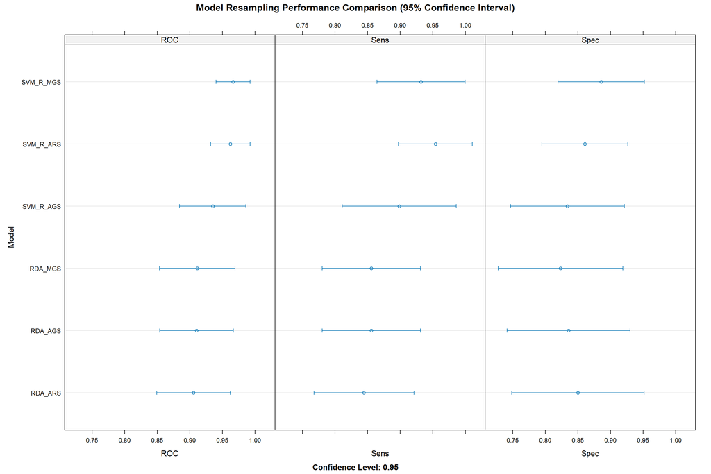

```r
dotplot(OverallResampling,
       main = "Model Resampling Performance Comparison (95% Confidence Interval)",
       ylab = "Model",
       pch=16,
       cex=2,
       layout=c(3,1))
```

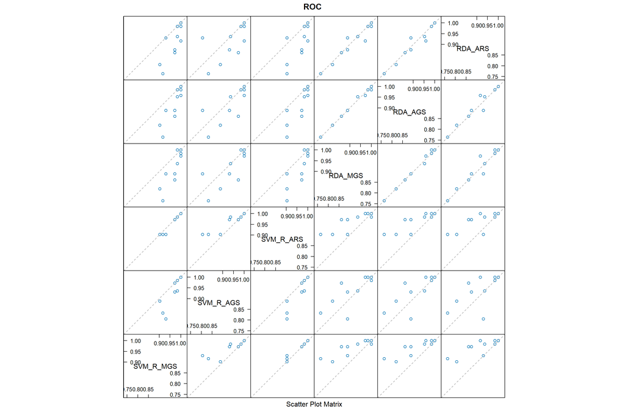

```r
splom(OverallResampling)
```

```r
##################################
# Conducting an analysis
# of the performance differences
##################################
(ResamplingDifferences <- diff(OverallResampling))
```

```
##
## Call:
## diff.resamples(x = OverallResampling)
##
## Models: SVM_R_MGS, SVM_R_AGS, SVM_R_ARS, RDA_MGS, RDA_AGS, RDA_ARS
## Metrics: ROC, Sens, Spec
## Number of differences: 15
## p-value adjustment: bonferroni
```

```r
summary(ResamplingDifferences)
```

```
##
## Call:
## summary.diff.resamples(object = ResamplingDifferences)
##
## p-value adjustment: bonferroni
## Upper diagonal: estimates of the difference
## Lower diagonal: p-value for H0: difference = 0
##
## ROC
##           SVM_R_MGS SVM_R_AGS SVM_R_ARS RDA_MGS   RDA_AGS   RDA_ARS
## SVM_R_MGS            0.031151  0.004167  0.054787  0.056151  0.060516
## SVM_R_AGS 0.74969             -0.026984  0.023636  0.025000  0.029365
## SVM_R_ARS 1.00000   0.57915              0.050620  0.051984  0.056349
## RDA_MGS   0.13881   1.00000   0.18357              0.001364  0.005729
## RDA_AGS   0.09628   1.00000   0.12814   1.00000              0.004365
## RDA_ARS   0.10637   1.00000   0.17953   1.00000   1.00000
##
## Sens
##           SVM_R_MGS SVM_R_AGS SVM_R_ARS RDA_MGS  RDA_AGS  RDA_ARS
## SVM_R_MGS            0.03333  -0.02222   0.07639  0.07639  0.08750
## SVM_R_AGS 1.0000              -0.05556   0.04306  0.04306  0.05417
## SVM_R_ARS 1.0000    1.0000               0.09861  0.09861  0.10972
## RDA_MGS   1.0000    1.0000    0.3158              0.00000  0.01111
## RDA_AGS   1.0000    1.0000    0.3158    NA                 0.01111
## RDA_ARS   1.0000    1.0000    0.2507    1.0000   1.0000
##
## Spec
##           SVM_R_MGS SVM_R_AGS SVM_R_ARS RDA_MGS   RDA_AGS   RDA_ARS
## SVM_R_MGS            0.051786  0.025000  0.062500  0.050000  0.035714
## SVM_R_AGS 0.5584              -0.026786  0.010714 -0.001786 -0.016071
## SVM_R_ARS 1.0000    1.0000               0.037500  0.025000  0.010714
## RDA_MGS   0.2243    1.0000    1.0000              -0.012500 -0.026786
## RDA_AGS   0.5518    1.0000    1.0000    1.0000              -0.014286
## RDA_ARS   1.0000    1.0000    1.0000    1.0000    1.0000
```

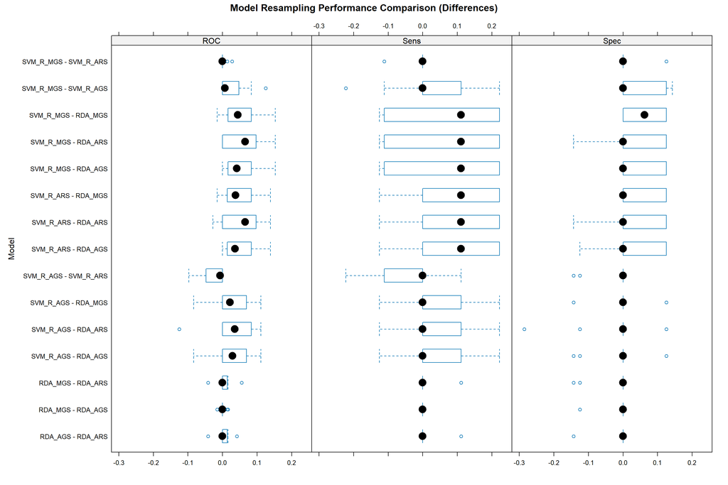

```r
bwplot(ResamplingDifferences,
       main = "Model Resampling Performance Comparison (Differences)",
       ylab = "Model",
       pch=16,
       cex=2,
       layout=c(3,1))
```

# **2. Summary**

[figure not shown]

# **3. References**

**[Book]** [Applied Predictive Modeling](http://appliedpredictivemodeling.com/) by Max Kuhn and Kjell Johnson  
**[Book]** [An Introduction to Statistical Learning](https://www.statlearning.com/) by Gareth James, Daniela Witten, Trevor Hastie and Rob Tibshirani  
**[Book]** [Multivariate Data Visualization with R](http://lmdvr.r-forge.r-project.org/figures/figures.html) by Deepayan Sarkar  
**[Book]** [Machine Learning](https://bookdown.org/ssjackson300/Machine-Learning-Lecture-Notes/) by Samuel Jackson  
**[Book]** [Data Modeling Methods](https://bookdown.org/larget_jacob/data-modeling-methods/) by Jacob Larget  
**[Book]** [Hyperparameter Tuning for Machine and Deep Learning with R](https://link.springer.com/book/10.1007/978-981-19-5170-1) by Eva Bartz, Thomas Bartz-Beielstein, Martin Zaefferer and Olaf Mersmann  
**[Book]** [Hyperparameter Optimization in Machine Learning](https://link.springer.com/book/10.1007/978-1-4842-6579-6) by Tanay Agrawal  
**[R Package]** [AppliedPredictiveModeling](https://cran.r-project.org/web//packages/AppliedPredictiveModeling/AppliedPredictiveModeling.pdf) by Max Kuhn  
**[R Package]** [caret](https://topepo.github.io/caret/index.html) by Max Kuhn  
**[R Package]** [rpart](https://mran.microsoft.com/web/packages/rpart/rpart.pdf) by Terry Therneau and Beth Atkinson  
**[R Package]** [lattice](https://cran.r-project.org/web/packages/lattice/lattice.pdf) by Deepayan Sarkar  
**[R Package]** [dplyr](https://cran.r-project.org/web/packages/dplyr/index.html/) by Hadley Wickham  
**[R Package]** [moments](https://cran.r-project.org/web/packages/moments/index.html) by Lukasz Komsta and Frederick  
**[R Package]** [skimr](https://cran.r-project.org/web/packages/skimr/skimr.pdf) by Elin Waring  
**[R Package]** [RANN](https://cran.r-project.org/web/packages/RANN/RANN.pdf) by Sunil Arya, David Mount, Samuel Kemp and Gregory Jefferis  
**[R Package]** [corrplot](https://cran.r-project.org/web/packages/corrplot/corrplot.pdf) by Taiyun Wei  
**[R Package]** [tidyverse](https://cran.r-project.org/web/packages/tidyverse/tidyverse.pdf) by Hadley Wickham  
**[R Package]** [lares](https://cran.rstudio.com/web/packages/lares/lares.pdf) by Bernardo Lares  
**[R Package]** [DMwR2](https://mran.microsoft.com/snapshot/2016-05-02/web/packages/DMwR/DMwR.pdf) by Luis Torgo  
**[R Package]** [gridExtra](https://cran.r-project.org/web/packages/gridExtra/gridExtra.pdf) by Baptiste Auguie and Anton Antonov  
**[R Package]** [rattle](https://cran.r-project.org/web/packages/rattle/rattle.pdf) by Graham Williams  
**[R Package]** [rpart.plot](https://cran.r-project.org/web/packages/rpart.plot/rpart.plot.pdf) by Stephen Milborrow  
**[R Package]** [RColorBrewer](https://cran.r-project.org/web//packages/RColorBrewer/RColorBrewer.pdf) by Erich Neuwirth  
**[R Package]** [stats](https://search.r-project.org/R/refmans/stats/html/00Index.html) by R Core Team  
**[R Package]** [pls](https://cran.r-project.org/web/packages/pls/pls.pdf) by Kristian Hovde Liland  
**[R Package]** [nnet](https://cran.r-project.org/web/packages/nnet/nnet.pdf) by Brian Ripley  
**[R Package]** [elasticnet](https://cran.r-project.org/web/packages/elasticnet/elasticnet.pdf) by Hui Zou  
**[R Package]** [earth](https://cran.r-project.org/web/packages/earth/earth.pdf) by Stephen Milborrow  
**[R Package]** [party](https://cran.r-project.org/web/packages/party/party.pdf) by Torsten Hothorn  
**[R Package]** [kernlab](https://cran.r-project.org/web/packages/kernlab/kernlab.pdf) by Alexandros Karatzoglou  
**[R Package]** [randomForest](https://cran.r-project.org/web/packages/randomForest/randomForest.pdf) by Andy Liaw  
**[R Package]** [pROC](https://cran.r-project.org/web/packages/pROC/pROC.pdf) by Xavier Robin  
**[R Package]** [mda](https://cran.r-project.org/web/packages/mda/mda.pdf) by Trevor Hastie  
**[R Package]** [klaR](https://cran.r-project.org/web/packages/klaR/klaR.pdf) by Christian Roever, Nils Raabe, Karsten Luebke, Uwe Ligges, Gero Szepannek, Marc Zentgraf and David Meyer  
**[R Package]** [pamr](https://cran.r-project.org/web/packages/pamr/pamr.pdf) by Trevor Hastie, Rob Tibshirani, Balasubramanian Narasimhan and Gil Chu  
**[Article]** [The caret Package](https://topepo.github.io/caret/index.html) by Max Kuhn  
**[Article]** [A Short Introduction to the caret Package](https://cran.r-project.org/web/packages/caret/vignettes/caret.html) by Max Kuhn  
**[Article]** Caret Package – A Practical Guide to Machine Learning in R by Selva Prabhakaran  
**[Article]** [Tuning Machine Learning Models Using the Caret R Package](https://machinelearningmastery.com/tuning-machine-learning-models-using-the-caret-r-package/) by Jason Brownlee  
**[Article]** [Hyperparameter Tuning for Machine Learning Explained](https://www.mygreatlearning.com/blog/hyperparameter-tuning-explained/) by Great Learning Team  
**[Article]** [Hyperparameter Tuning](https://www.geeksforgeeks.org/hyperparameter-tuning/) by Tarandeep Singh  
**[Article]** [Hyperparameter Optimization Techniques to Improve Your Machine Learning Model’s Performance](https://www.freecodecamp.org/news/hyperparameter-optimization-techniques-machine-learning/) by Davis David  
**[Article]** [What Is Hyperparameter Tuning?](https://aws.amazon.com/what-is/hyperparameter-tuning/) by AWS Team  
**[Article]** Hyperparameter Tuning in Python: a Complete Guide by Shahul ES and Aayush Bajaj  
**[Article]** [Lattice Graphs](http://www.sthda.com/english/wiki/lattice-graphs) by Alboukadel Kassambara  
**[Article]** [A Tour of Machine Learning Algorithms](https://machinelearningmastery.com/a-tour-of-machine-learning-algorithms/) by Jason Brownlee  
**[Article]** [Decision Tree Algorithm Examples In Data Mining](https://www.softwaretestinghelp.com/decision-tree-algorithm-examples-data-mining/) by Software Testing Help Team  
**[Article]** [4 Types of Classification Tasks in Machine Learning](https://machinelearningmastery.com/types-of-classification-in-machine-learning/) by Jason Brownlee  
**[Article]** [Spot-Check Classification Machine Learning Algorithms in Python with scikit-learn](https://machinelearningmastery.com/spot-check-classification-machine-learning-algorithms-python-scikit-learn/) by Jason Brownlee  
**[Article]** [Feature Engineering and Selection: A Practical Approach for Predictive Models](http://www.feat.engineering/index.html) by Max Kuhn and Kjell Johnson  
**[Article]** [An Introduction to Naive Bayes Algorithm for Beginners](https://www.turing.com/kb/an-introduction-to-naive-bayes-algorithm-for-beginners) by Turing Team  
**[Article]** [Machine Learning Tutorial: A Step-by-Step Guide for Beginners](http://www.feat.engineering/index.html) by Mayank Banoula  
**[Article]** [Nearest Shrunken Centroids With Python](https://machinelearningmastery.com/nearest-shrunken-centroids-with-python/) by Jason Brownlee  
**[Article]** [Discriminant Analysis Essentials in R](http://www.sthda.com/english/articles/36-classification-methods-essentials/146-discriminant-analysis-essentials-in-r/) by Alboukadel Kassambara  
**[Article]** [Linear Discriminant Analysis, Explained](https://yangxiaozhou.github.io/data/2019/10/02/linear-discriminant-analysis.html) by Xiaozhou Yang  
**[Article]** Flexible Discriminant Analysis by BCCVL Team  
**[Article]** [Classification Tree](https://support.bccvl.org.au/support/solutions/articles/6000083204-classification-tree) by BCCVL Team  
**[Article]** [Random Forest](https://support.bccvl.org.au/support/solutions/articles/6000083217-random-forest) by BCCVL Team  
**[Article]** [Boosted Regression Tree](https://support.bccvl.org.au/support/solutions/articles/6000083202-boosted-regression-tree) by BCCVL Team  
**[Article]** [Artificial Neural Network](https://support.bccvl.org.au/support/solutions/articles/6000083200-artificial-neural-network) by BCCVL Team  
**[Article]** [Generalized Linear Model](https://support.bccvl.org.au/support/solutions/articles/6000083213-generalized-linear-model) by BCCVL Team  
**[Article]** [Classification Tree](https://support.bccvl.org.au/support/solutions/articles/6000083204-classification-tree) by BCCVL Team  
**[Article]** [Generalized Boosting Model](https://support.bccvl.org.au/support/solutions/articles/6000083212-generalized-boosting-model) by BCCVL Team  
**[Article]** [C5.0: An Informal Tutorial](https://www.rulequest.com/see5-unix.html) by RuleQuest Team  
**[Article]** [What is Nearest Shrunken Centroid Classification?](https://www.tibshirani.su.domains/PAM/Rdist/howwork.html) by Rob Tibshirani  
**[Article]** [Regularized Discriminant Analysis](https://www.geeksforgeeks.org/regularized-discriminant-analysis/) by Geeks For Geeks Team  
**[Article]** Linear, Quadratic, and Regularized Discriminant Analysis by Data Science Blog Team  
**[Article]** [Regularized Discriminant Analysis](https://data-farmers.github.io/2019-06-25-Regularized-Discriminant-Analysis/) by Data Farmers  
**[Publication]** [A Training Algorithm for Optimal Margin Classifiers](https://dl.acm.org/doi/10.1145/130385.130401) by Bernhard Boser, Isabelle Guyon and Vladimir Vapnik (Proceedings of the Fifth Annual Workshop on Computational Learning Theory)  
**[Publication]** [Regularized Discriminant Analysis](https://www.tandfonline.com/doi/abs/10.1080/01621459.1989.10478752) by Jerome Friedman (Journal of the American Statistical Association)  
**[Publication]** [Estimating the Error Rate of a Prediction Rule: Improvement on Cross-Validation](https://www.tandfonline.com/doi/abs/10.1080/01621459.1983.10477973) by Bradley Efron (Journal of the American Statistical Association)  
**[Publication]** [How Biased is the Apparent Error Rate of a Prediction Rule?](https://www.tandfonline.com/doi/abs/10.1080/01621459.1986.10478291) by Bradley Efron (Journal of the American Statistical Association)  
**[Publication]** [Prediction Error Estimation: A Comparison of Resampling Methods](https://academic.oup.com/bioinformatics/article/21/15/3301/195433) by Annette Molinaro, Richard Simon and Ruth Pfeiffer (Bioinformatics)  
**[Course]** [Applied Data Mining and Statistical Learning](https://online.stat.psu.edu/stat508/) by Penn State Eberly College of Science  
**[Course]** [Regression Methods](https://online.stat.psu.edu/stat501/) by Penn State Eberly College of Science  
**[Course]** [Applied Regression Analysis](https://online.stat.psu.edu/stat462/) by Penn State Eberly College of Science  
**[Course]** [Applied Data Mining and Statistical Learning](https://online.stat.psu.edu/stat508/) by Penn State Eberly College of Science